# Transcriptional response to COVID-19 infection

Bernardo Carraro Detanico

18 May 2020

## 1. Introduction

The new coronavirus disease (COVID-19), caused by the severe acute respiratory syndrome coronavirus 2 (SARS-CoV-2), has quickly become a global health emergency.

> Scientists are working around the clock to understand the biology of the SARS-CoV-2 and how infected human cells respond to it.

In this context, the current project analysed the transcriptional response to SARS-CoV-2 infection using RNA-sequencing data from a cell model of SARS-CoV-2 infection and COVID-19 lung biopsy from *post mortem* COVID-19 patient. The data, obtained from Gene Expression Omnibus (https://www.ncbi.nlm.nih.gov/geo/query/acc.cgi?acc=GSE147507), came from the paper: *Daniel Blanco-Melo, Benjamin E. Nilsson-Payant, Wen-Chun Liu, Rasmus Møller, Maryline Panis, David Sachs, Randy A. Albrecht, Benjamin R. tenOever. **SARS-CoV-2 launches a unique transcriptional signature from in vitro, ex vivo, and in vivo systems**. bioRxiv 2020.03.24.004655*.

## 2. Loading packages

```r
library(tidyverse)
library(GEOquery)
library(dplyr)
library(DESeq2)
library(pheatmap)
library(gridExtra)
library(grid)
library(formattable)
library(ggrepel)
library(biomaRt)
library(org.Hs.eg.db)
library(clusterProfiler)
library(enrichplot)
library(DOSE)
library(pathview)
```

## 3. Reading files

```r
matrix <- getGEO(filename="GSE147507-GPL18573_series_matrix.txt")
matrix <- pData(matrix)[1:69,]

data_raw <- read.csv(file = 'GSE147507_RawReadCounts_Human.tsv', header = TRUE, sep = "\t", row.names="X")

head(data_raw, 2)
```

```
##         Series1_NHBE_Mock_1 Series1_NHBE_Mock_2 Series1_NHBE_Mock_3
## DDX11L1                   0                   0                   0
## WASH7P                   29                  24                  23
##         Series1_NHBE_SARS.CoV.2_1 Series1_NHBE_SARS.CoV.2_2
## DDX11L1                         0                         0
## WASH7P                         34                        19
##         Series1_NHBE_SARS.CoV.2_3 Series2_A549_Mock_1 Series2_A549_Mock_2
## DDX11L1                         0                   0                   0
## WASH7P                         44                  68                  43
##         Series2_A549_Mock_3 Series2_A549_SARS.CoV.2_1 Series2_A549_SARS.CoV.2_2
## DDX11L1                   0                         0                         1
## WASH7P                   33                        65                        79
##         Series2_A549_SARS.CoV.2_3 Series3_A549_Mock_1 Series3_A549_Mock_2
## DDX11L1                         1                   1                   0
## WASH7P                         48                 184                 128
##         Series3_A549_RSV_1 Series3_A549_RSV_2 Series4_A549_Mock_1
## DDX11L1                  0                  0                   0
## WASH7P                  51                 43                  15
##         Series4_A549_Mock_2 Series4_A549_IAV_1 Series4_A549_IAV_2
## DDX11L1                   0                  0                  0
## WASH7P                   12                  3                  3
##         Series5_A549_Mock_1 Series5_A549_Mock_2 Series5_A549_Mock_3
## DDX11L1                   0                   0                   0
## WASH7P                   64                  53                  37
##         Series5_A549_SARS.CoV.2_1 Series5_A549_SARS.CoV.2_2
## DDX11L1                         0                         0
## WASH7P                         38                        47
##         Series5_A549_SARS.CoV.2_3 Series6_A549.ACE2_Mock_1
## DDX11L1                         0                        0
## WASH7P                         65                       37
##         Series6_A549.ACE2_Mock_2 Series6_A549.ACE2_Mock_3
## DDX11L1                        0                        0
## WASH7P                         4                       22
##         Series6_A549.ACE2_SARS.CoV.2_1 Series6_A549.ACE2_SARS.CoV.2_2
## DDX11L1                              0                              0
## WASH7P                               1                              2
##         Series6_A549.ACE2_SARS.CoV.2_3 Series7_Calu3_Mock_1
## DDX11L1                              0                    0
## WASH7P                               4                   25
##         Series7_Calu3_Mock_2 Series7_Calu3_Mock_3 Series7_Calu3_SARS.CoV.2_1
```

[output cut: 23 more lines]

```
##         Series9_NHBE_IAVdNS1_2 Series9_NHBE_IAVdNS1_3 Series9_NHBE_IAVdNS1_4
## DDX11L1                      0                      0                      0
## WASH7P                      56                     36                    131
##         Series9_NHBE_IFNB_4h_1 Series9_NHBE_IFNB_4h_2 Series9_NHBE_IFNB_6h_1
## DDX11L1                      0                      0                      0
## WASH7P                      72                     66                     46
##         Series9_NHBE_IFNB_6h_2 Series9_NHBE_IFNB_12h_1 Series9_NHBE_IFNB_12h_2
## DDX11L1                      0                       0                       0
## WASH7P                      35                      48                      46
##         Series15_HealthyLungBiopsy_2 Series15_HealthyLungBiopsy_1
## DDX11L1                            0                            0
## WASH7P                           261                          140
##         Series15_COVID19Lung_2 Series15_COVID19Lung_1
## DDX11L1                      0                      0
## WASH7P                       0                      0
```

This is the read counts associated with genes. The count data used for differential expression analysis represent the number of sequence reads that originated from a particular gene. The higher the number of counts, the more reads associated with that gene, and the assumption that there is a higher level of expression of that gene in the sample.

## 4. Selecting the data

The data were cleaned in order to keep only the series of interest:

- NHBE cells (primary human bronchial epithelial cells) infected with SARS-CoV-2, and NHBE cells control (mock treated).
- Lung biopsy sample from *post mortem* COVID-19 patient, and healthy negative control patient.

```r
keep.list <- paste(c("Series1", "Series15"), collapse = '|')
#remove.list <- c(1:6, 25:28)

data_raw <- data_raw[, grepl(keep.list, colnames(data_raw))]
#data_raw <- data_raw[, remove.list]
matrix <- matrix[grepl(keep.list, matrix$title),]
#matrix <- matrix[remove.list,]
```

After selecting the data, the project analysed 2 series of experiments, each one composed of control and infected groups, as detailed below:

```r
unique(matrix$source_name_ch1)
```

```
## [1] "Mock treated NHBE cells"
## [2] "SARS-CoV-2 infected NHBE cells"
## [3] "Lung biopsy for heatly negative control"
## [4] "Lung sample from postmortem COVID-19 patient"
```

## 5. Determining the statistical model

To determine the appropriate statistical model, the distribution of counts analysis is mandatory. As an example, the “Mock treated NHBE cells” and “Lung biopsy for healthy negative control” groups were chosen.

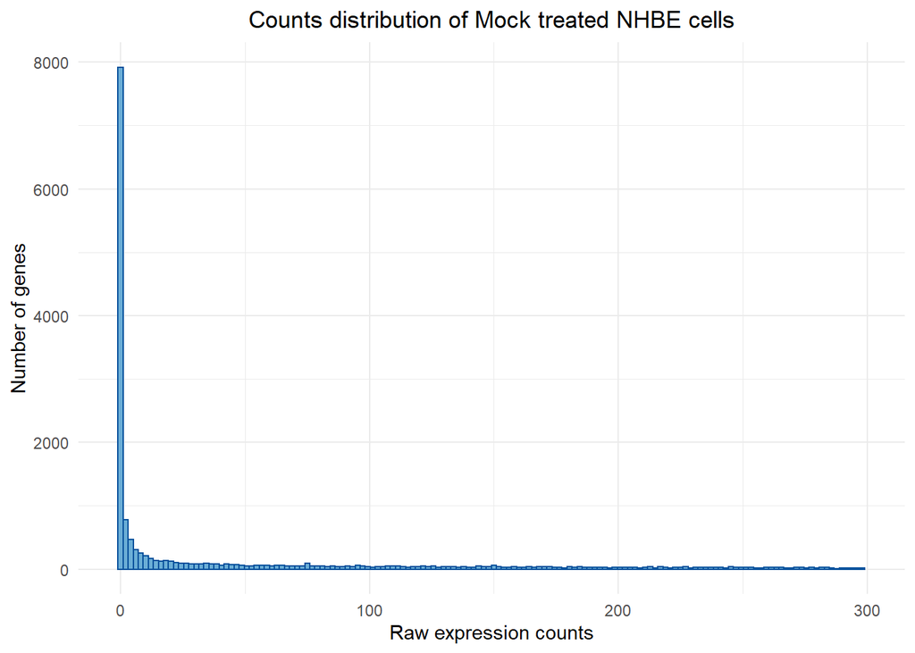

```r
ggplot(data_raw, aes(x = Series1_NHBE_Mock_1)) +
  geom_histogram(stat = "bin", bins = 150, color = "#08519c", fill = "#6baed6") +
  xlim(-2, 300) +
  xlab("Raw expression counts") +
  ylab("Number of genes") +
  theme_minimal() +
  ggtitle("Counts distribution of Mock treated NHBE cells") +
  theme(plot.title = element_text(hjust = 0.5))
```

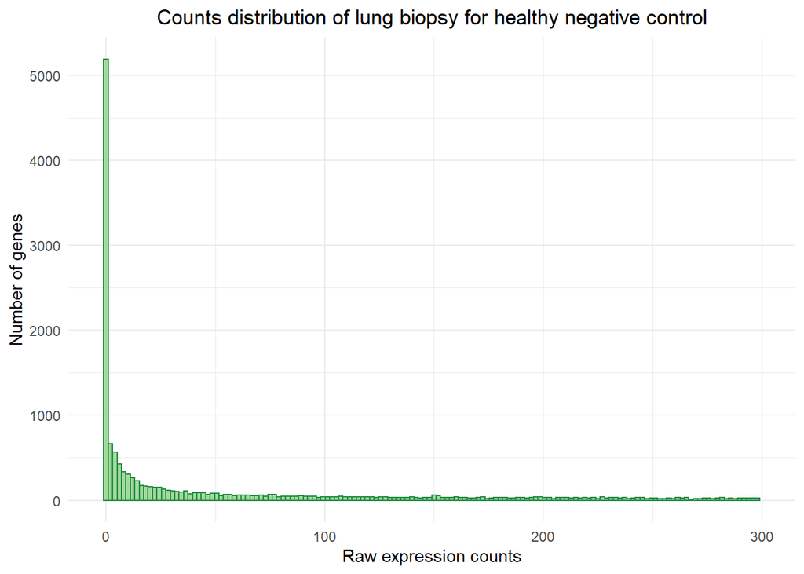

```r
ggplot(data_raw, aes(x = Series15_HealthyLungBiopsy_2)) +
  geom_histogram(position="identity", stat = "bin", bins = 150, color = "#238b45", fill = "#a1d99b") +
  xlim(-2, 300) +
  xlab("Raw expression counts") +
  ylab("Number of genes") +
  theme_minimal() +
  ggtitle("Counts distribution of lung biopsy for healthy negative control") +
  theme(plot.title = element_text(hjust = 0.5))
```

- Both plots illustrate a common feature of RNA-seq count data: **a low number of counts associated with a large proportion of genes, and a long right tail**.

Additionally, to choose the appropriate statistical model, it can be helpful to plot the mean versus the variance of the data.

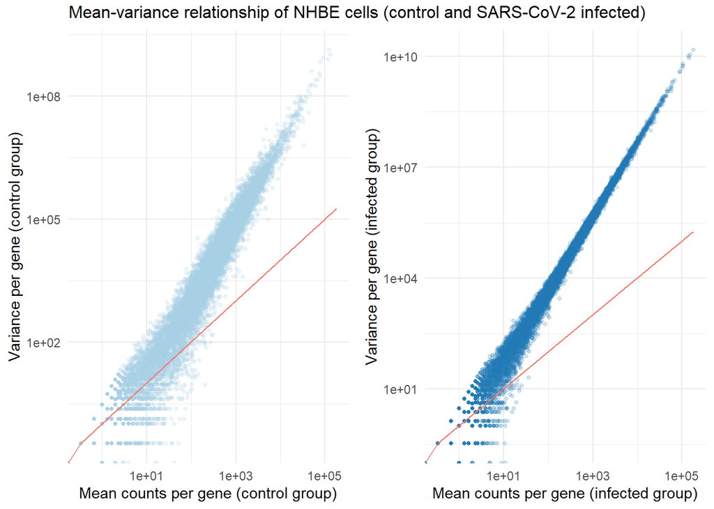

```r
# Mean-variance relationship
control_col <- c(1, 2, 3)
infected_col <- c(4, 5, 6)

# Calculating mean for each gene (each row)
mean_counts_c <- apply(data_raw[, control_col], 1, mean) # control
mean_counts_i <- apply(data_raw[, infected_col], 1, mean) # infected

# Calculating variance for each gene
var_counts_c <- apply(data_raw[, control_col], 1, var) # control
var_counts_i <- apply(data_raw[, infected_col], 1, var) # infected

# Creating data frame with mean and variance for every gene
df_c <- data.frame(mean_counts_c, var_counts_c)

p1 <- ggplot(df_c) +
        geom_point(aes(x=mean_counts_c, y=var_counts_c), size = 1, alpha = 1/5, color = "#a6cee3") +
        geom_line(aes(x=mean_counts_i, y=mean_counts_i, color="red")) +
        scale_y_log10() +
        scale_x_log10() +
        xlab("Mean counts per gene (control group)") +
        ylab("Variance per gene (control group)") +
        theme_minimal() +
        theme(legend.position="none")


df_i <- data.frame(mean_counts_i, var_counts_i)

p2 <- ggplot(df_i) +
        geom_point(aes(x=mean_counts_i, y=var_counts_i), size = 1, alpha = 1/5, color = "#1f78b4") +
        geom_line(aes(x=mean_counts_i, y=mean_counts_i, color="red")) +
        scale_y_log10() +
        scale_x_log10() +
        xlab("Mean counts per gene (infected group)") +
        ylab("Variance per gene (infected group)") +
        theme_minimal() +
        theme(legend.position="none")

grid.arrange(p1, p2, ncol=2, top = "Mean-variance relationship of NHBE cells (control and SARS-CoV-2 infected)")
```

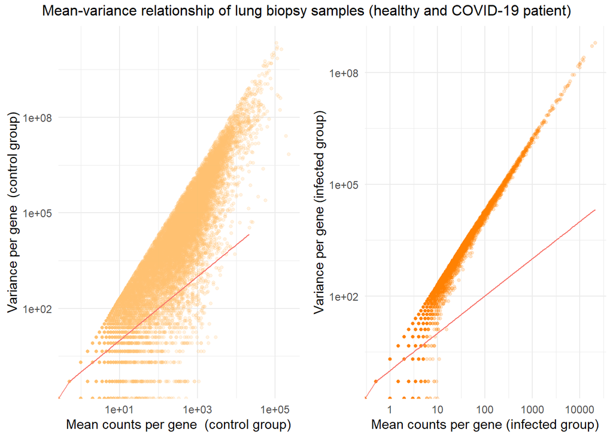

```r
# Mean-variance relationship

control_col <- c(7, 8)
infected_col <- c(9, 10)

# Calculating mean for each gene (each row)
mean_counts_c <- apply(data_raw[, control_col], 1, mean) # control
mean_counts_i <- apply(data_raw[, infected_col], 1, mean) # infected

# Calculating variance for each gene
var_counts_c <- apply(data_raw[, control_col], 1, var) # control
var_counts_i <- apply(data_raw[, infected_col], 1, var) # infected

# Creating data frame with mean and variance for every gene
df_c <- data.frame(mean_counts_c, var_counts_c)

p1 <- ggplot(df_c) +
        geom_point(aes(x=mean_counts_c, y=var_counts_c), size = 1, alpha = 1/5, color = "#fdbf6f") +
        geom_line(aes(x=mean_counts_i, y=mean_counts_i, color="red")) +
        scale_y_log10() +
        scale_x_log10() +
        xlab("Mean counts per gene  (control group)") +
        ylab("Variance per gene  (control group)") +
        theme_minimal() +
        theme(legend.position="none")


df_i <- data.frame(mean_counts_i, var_counts_i)

p2 <- ggplot(df_i) +
        geom_point(aes(x=mean_counts_i, y=var_counts_i), size = 1, alpha = 1/5, color = "#ff7f00") +
        geom_line(aes(x=mean_counts_i, y=mean_counts_i, color="red")) +
        scale_y_log10() +
        scale_x_log10() +
        xlab("Mean counts per gene (infected group)") +
        ylab("Variance per gene (infected group)") +
        theme_minimal() +
        theme(legend.position="none")

grid.arrange(p1, p2, ncol=2, top = "Mean-variance relationship of lung biopsy samples (healthy and COVID-19 patient)")
```

- All plots have a similar pattern: the variance across the replicates tends to be greater than the mean (**red** line): $mean < variance$. Besides, the variation in gene expression increases with the mean. This is expected for RNA-seq data.

> This results (distribution of counts **AND** $mean < variance$) suggest that **the RNA-seq data can be modelled well using the negative binomial model**. Another option could be Poisson distribution model, however, a unique property of this distribution is that the $mean == variance$.

## 6. Differential expression analysis

`DESeq2` package was used to model the raw counts using normalization factors for library size and RNA composition between samples. `DESeq2` uses the negative binomial model and perform hypothesis testing using the Wald test (also called the Wald Chi-Squared Test) or Likelihood Ratio Test.

To compare counts for the same gene between different samples, it’s needed to **normalize** the raw counts. `DESeq2` performs an internal normalization which geometric mean is calculated for each gene across all samples. The counts for a gene in each sample is then divided by this mean. The median of these ratios in a sample is the size factor for that sample. This procedure corrects for library size and RNA composition bias.

Before creating `DESEq2` object, the **metadata table** was built.

```r
# Create type vector
type <- matrix$`cell line:ch1`
type[1:6] = "NHBE-Series1"
type[is.na(type)] = "Lung biopsy-Series15"

# Create condition vector
condition <- matrix$source_name_ch1

# Create data frame
metadata <- data.frame(type, condition)

# Assign the row names of the data frame
rownames(metadata) <- matrix$title

metadata
```

```
##                                              type
## Series1_NHBE_Mock_1                  NHBE-Series1
## Series1_NHBE_Mock_2                  NHBE-Series1
## Series1_NHBE_Mock_3                  NHBE-Series1
## Series1_NHBE_SARS-CoV-2_1            NHBE-Series1
## Series1_NHBE_SARS-CoV-2_2            NHBE-Series1
## Series1_NHBE_SARS-CoV-2_3            NHBE-Series1
## Series15_HealthyLungBiopsy_1 Lung biopsy-Series15
## Series15_HealthyLungBiopsy_2 Lung biopsy-Series15
## Series15_COVID19Lung_1       Lung biopsy-Series15
## Series15_COVID19Lung_2       Lung biopsy-Series15
##                                                                 condition
## Series1_NHBE_Mock_1                               Mock treated NHBE cells
## Series1_NHBE_Mock_2                               Mock treated NHBE cells
## Series1_NHBE_Mock_3                               Mock treated NHBE cells
## Series1_NHBE_SARS-CoV-2_1                  SARS-CoV-2 infected NHBE cells
## Series1_NHBE_SARS-CoV-2_2                  SARS-CoV-2 infected NHBE cells
## Series1_NHBE_SARS-CoV-2_3                  SARS-CoV-2 infected NHBE cells
## Series15_HealthyLungBiopsy_1      Lung biopsy for heatly negative control
## Series15_HealthyLungBiopsy_2      Lung biopsy for heatly negative control
## Series15_COVID19Lung_1       Lung sample from postmortem COVID-19 patient
## Series15_COVID19Lung_2       Lung sample from postmortem COVID-19 patient
```

### **6.1. NHBE cells infected with SARS-CoV-2**

- This section (**6.1.**) analyses the NHBE cells SARS-CoV-2 infected experiment. The section **6.2.** analyses the lung biopsy experiment.

```r
# Building the DESeq2 object
remove.list <- paste(c("Series9", "Series15"), collapse = '|')
dds_NHBE_Series1 <- DESeqDataSetFromMatrix(countData = data_raw[, !grepl(remove.list, colnames(data_raw))],
                              colData = metadata[!grepl(remove.list, metadata$type),],
                              design = ~ condition)


head(counts(dds_NHBE_Series1)) #Counts
```

```
##           Series1_NHBE_Mock_1 Series1_NHBE_Mock_2 Series1_NHBE_Mock_3
## DDX11L1                     0                   0                   0
## WASH7P                     29                  24                  23
## FAM138A                     0                   0                   0
## FAM138F                     0                   0                   0
## OR4F5                       0                   0                   0
## LOC729737                 112                 119                 113
##           Series1_NHBE_SARS-CoV-2_1 Series1_NHBE_SARS-CoV-2_2
## DDX11L1                           0                         0
## WASH7P                           34                        19
## FAM138A                           0                         0
## FAM138F                           0                         0
## OR4F5                             0                         0
## LOC729737                       127                        84
##           Series1_NHBE_SARS-CoV-2_3
## DDX11L1                           0
## WASH7P                           44
## FAM138A                           0
## FAM138F                           0
## OR4F5                             0
## LOC729737                       270
```

#### 6.1.1. Quality assessment

This procedure checks the count data to ensure that the samples/replicates look good. For this purpose, hierarchical clustering (HC) and principal component analysis (PCA) methods were applied.

```r
dds <- estimateSizeFactors(dds_NHBE_Series1)
#sizeFactors(dds)

normalized_counts <- counts(dds, normalized=TRUE)
```

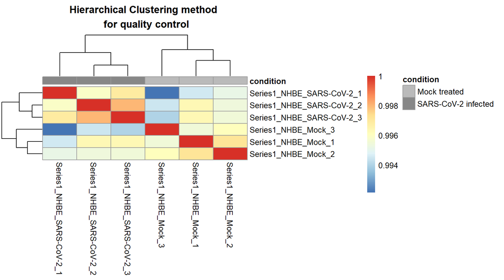

```r
dds_log <- vst(dds, blind=TRUE)
dds_log_matrix <- assay(dds_log) # Matrix

vsd_corr <- cor(dds_log_matrix)

ann_colors = list(condition = c("Mock treated" = "#bababa", "SARS-CoV-2 infected" = "#878787"))

metadata_n <- metadata
metadata_n$condition <- gsub(' NHBE cells', '', metadata$condition)

pheatmap(vsd_corr,
         annotation = select(metadata_n, condition),
         annotation_colors = ann_colors,
         annotation_legend = TRUE,
         main = "Hierarchical Clustering method \n for quality control")
```

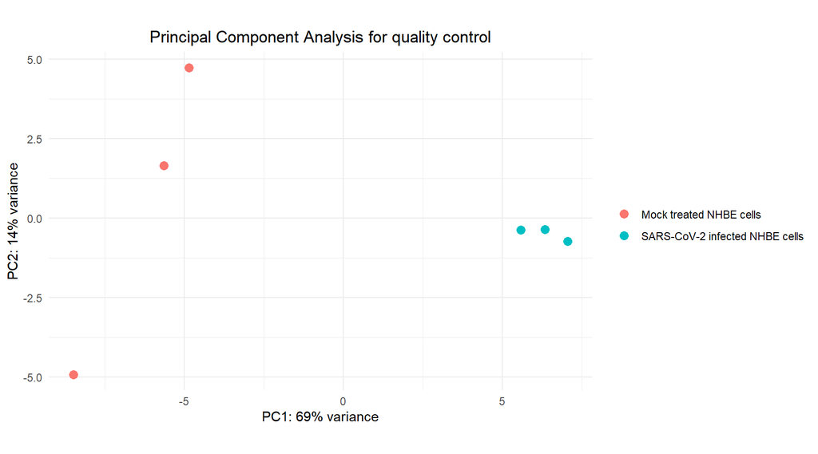

```r
plotPCA(dds_log, intgroup = "condition") +
  theme_minimal() +
  ggtitle("Principal Component Analysis for quality control") +
  theme(plot.title = element_text(hjust = 0.5), legend.title = element_blank())
```

- The PC1 explains the most variation in the data (69% of variance). The control “cluster” and infected cluster are separated on PC1. It seems that a lot of variation in gene expression can be explained by conditions (control vs SARS-CoV-2 infected).

> Together, **these quality controls suggest that the data are of reasonable quality**.

#### 6.1.2. Running DESeq2 - differential expression analysis

```r
dds_NHBE_Series1 <- DESeq(dds_NHBE_Series1)
```

The function `DESeq()` performed the following procedures:  
- estimating size factors  
- estimating dispersions  
- gene-wise dispersion estimates  
- mean-dispersion relationship  
- final dispersion estimates  
- fitting model and testing

`DESeq2` model uses estimated dispersion to assess the variability in expression when modelling the counts. Each black dot represents a gene. Genes with low dispersion estimates are shrunken towards the curve.

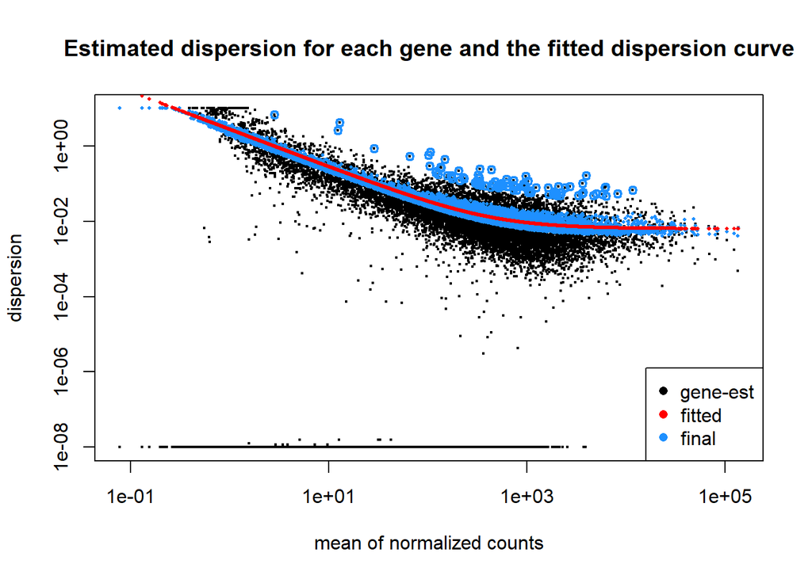

```r
plotDispEsts(dds_NHBE_Series1, main = "Estimated dispersion for each gene and the fitted dispersion curve")
```

> The dispersion in gene expression decreases with increasing mean. The fit of the data to the model is good since the dispersions decrease with increasing mean and cluster around the maximum likelihood (ML) line. It’s expected that the data scatter around the curve, with the dispersion decreasing with increasing mean expression levels.

$$↑variation ⇒ ↑dispersion$$
$$↑mean ⇒ ↓dispersion$$

As already commented, `DESeq2` uses a negative binomial distribution to model the RNA-seq counts, and the coefficients are the estimates for the log2 foldchanges for each sample group. **To generate more accurate log2 foldchange estimates (effect size), the `DESeq2` authors recommend “shrinking” the log fold-changes which is available in `DESeq2’s` `lfcShrink` function**. The unshrunken results (1) and shrunken results (2) were performed.

```r
dds_NHBE_Series1_result_1 <- results(dds_NHBE_Series1,
            contrast = c("condition", "SARS-CoV-2 infected NHBE cells", "Mock treated NHBE cells"),
            alpha = 0.01)

#coef(dds_NHBE)[1,]
dds_NHBE_Series1_result_2 <- lfcShrink(dds_NHBE_Series1,
            coef= "condition_SARS.CoV.2.infected.NHBE.cells_vs_Mock.treated.NHBE.cells",
            type="apeglm")
```

The `MA plot` can be useful to explore the results. The log2 fold change is plotted on the y-axis, the average of the counts normalized by size factor is shown on the x-axis. Each gene is represented with a dot, and the genes that are significantly differentially expressed are coloured **blue**.

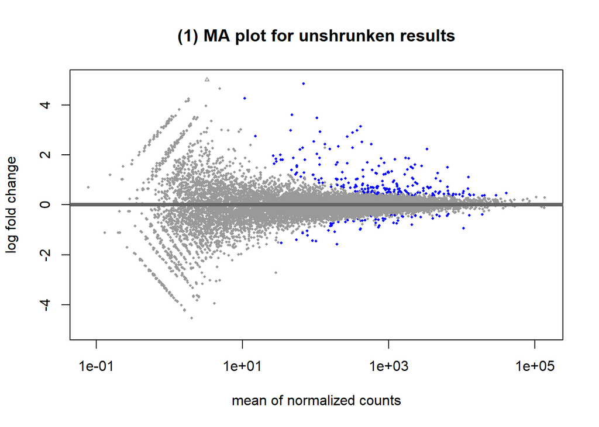

```r
# The MA plot shows the mean of normalized count versus the log2 fold changes for all genes tested.
plotMA(dds_NHBE_Series1_result_1, ylim=c(-5,5), main = "(1) MA plot for unshrunken results")
```

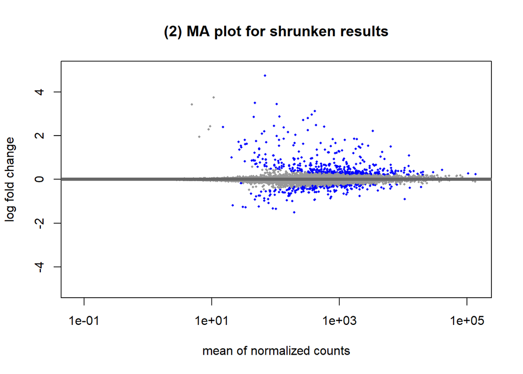

```r
plotMA(dds_NHBE_Series1_result_2, ylim=c(-5,5), main = "(2) MA plot for shrunken results")
```

`MA plots` often display a fanning-effect at the left-hand side (genes with low numbers of counts) due to the high variability of the measurements for these genes. These plots demonstrate that only genes with a large average normalized count contain sufficient information to yield a significant call.

> **The shrunken results (second plot) were more stable fold change values**. So, the shrunken results were used.

#### 6.1.3. Results

```r
head(dds_NHBE_Series1_result_2)
```

```
## log2 fold change (MAP): condition SARS.CoV.2.infected.NHBE.cells vs Mock.treated.NHBE.cells
## Wald test p-value: condition SARS.CoV.2.infected.NHBE.cells vs Mock.treated.NHBE.cells
## DataFrame with 6 rows and 5 columns
##            baseMean log2FoldChange     lfcSE    pvalue      padj
##           <numeric>      <numeric> <numeric> <numeric> <numeric>
## DDX11L1      0.0000             NA        NA        NA        NA
## WASH7P      29.1301      0.0101653  0.122305  0.761453  0.943622
## FAM138A      0.0000             NA        NA        NA        NA
## FAM138F      0.0000             NA        NA        NA        NA
## OR4F5        0.0000             NA        NA        NA        NA
## LOC729737  130.4224      0.0335934  0.116369  0.532518  0.870954
```

- **baseMean:** average of the normalized count values, divided by size factors, taken over all samples.
- **log2FoldChange:** the effect size estimated, which is a measure describing how much the gene’s expression is different between control and infected groups. This value is reported as base 2 logarithmic scale. A log2 fold change of 1 ($\log2(FC) = 1$) means that the gene’s expression is increased by a multiplicative factor of $2^1 = 2$.
- **lfcSE:** standard error estimated for the log2 fold change estimated.
- **pvalue:** Wald test p-value for $p < 0.01$.
- **padj:** false discovery rate (FDR)/Benjamini-Hochberg (BH) adjusted p-values, to control the false positives.

```r
summary(dds_NHBE_Series1_result_2)
```

```
##
## out of 16360 with nonzero total read count
## adjusted p-value < 0.1
## LFC > 0 (up)       : 404, 2.5%
## LFC < 0 (down)     : 191, 1.2%
## outliers [1]       : 0, 0%
## low counts [2]     : 4363, 27%
## (mean count < 12)
## [1] see 'cooksCutoff' argument of ?results
## [2] see 'independentFiltering' argument of ?results
```

> The result was **595 (sum of LFC: log2 fold changes) genes with differential expression** of a total of 16360 with non-zero total read count. This summary represents the number of genes that were considered up- and down-regulated according to the Wald test.

Using any cut-off (padj and/or threshold values) can be helpful when dealing with large numbers of differentially expressed genes. However, it increases the risk of losing biologically relevant gene.

- By specifying a threshold equal to 1 for log2 fold change values ($\log2(FC) = 1$), then $foldchange = 2^1$ between infected and control groups for gene counts. The infected group count is twice as big as control (infected is 200% of control).
- If ($\log2(FC) = -1$), then $Fold Change = 2^{-1}$ between infected and control groups for gene counts. The infected group count is half as big as control (infected is 50% of control).

```r
dds_NHBE_Series1_result_2_ <- dds_NHBE_Series1_result_2 %>%
  data.frame() %>%
  rownames_to_column(var="gene")

dds_NHBE_Series1_result_2_sig <- dds_NHBE_Series1_result_2_ %>%
        filter(padj < 0.01 & abs(log2FoldChange) > 1)

nrow(dds_NHBE_Series1_result_2_sig)
```

```
## [1] 82
```

> After applying the cut-offs $padj < 0.01$ & $abs(log2FoldChange) > 1$, **the number of significant differentially expressed genes was 82.**

```r
NHBE_Series1_result <- dds_NHBE_Series1_result_2_sig[order(dds_NHBE_Series1_result_2_sig$padj),]
rownames(NHBE_Series1_result) <- NULL
as.datatable(formattable(NHBE_Series1_result,
                         list(
                           log2FoldChange = color_tile("#ffffff", "#6baed6"),
                           padj = color_tile("#74c476", "#e5f5e0"),
                           `gene` = formatter(
              "span", style = ~ style(color = "grey",font.weight = "bold")))))
```

|  | gene | baseMean | log2FoldChange | lfcSE | pvalue | padj |
| --- | --- | --- | --- | --- | --- | --- |
| 1 | CCL20 | 412.11462 | 3.126680 | 0.16619701 | 3.261031e-80 | 3.912259e-76 |
| 2 | SAA2 | 575.76687 | 2.409017 | 0.12883145 | 3.397564e-79 | 2.038029e-75 |
| 3 | SAA1 | 3315.93608 | 2.204641 | 0.13926855 | 8.608422e-58 | 3.442508e-54 |
| 4 | S100A8 | 1706.97277 | 1.853742 | 0.12224434 | 2.915205e-53 | 6.994744e-50 |
| 5 | IL36G | 271.32430 | 2.709085 | 0.17857310 | 2.368277e-53 | 6.994744e-50 |
| 6 | TNFAIP3 | 2288.72151 | 1.598602 | 0.10632673 | 2.409948e-52 | 4.818690e-49 |
| 7 | SPRR2D | 365.19782 | 2.953864 | 0.19806921 | 1.755726e-51 | 3.009063e-48 |
| 8 | INHBA | 1216.84142 | 1.803353 | 0.12146020 | 5.176983e-51 | 7.763534e-48 |
| 9 | C3 | 6335.74147 | 1.493901 | 0.10638344 | 4.322969e-46 | 5.762517e-43 |
| 10 | KRT6B | 2803.30818 | 1.533163 | 0.10955763 | 9.846400e-46 | 1.181273e-42 |

[output cut: 72 more lines]

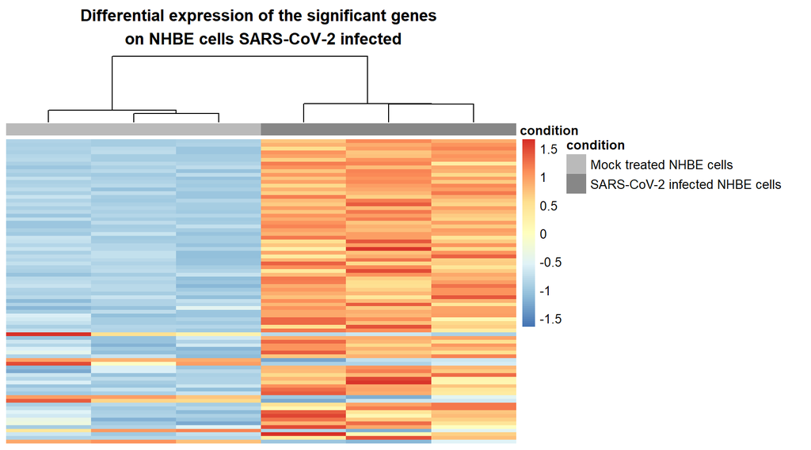

```r
sig_norm_counts <- normalized_counts[NHBE_Series1_result$gene, ]

select <- sig_norm_counts[1:82,]

ann_colors = list(condition = c("Mock treated NHBE cells" = "#bababa", "SARS-CoV-2 infected NHBE cells" = "#878787"))
pheatmap(select,
         cluster_rows = FALSE,
         show_rownames = FALSE,
         show_colnames = FALSE,
         border_color = NA,
         annotation = select(metadata, condition),
         annotation_colors = ann_colors,
         scale = "row",
         main = "Differential expression of the significant genes \n on NHBE cells SARS-CoV-2 infected")
```

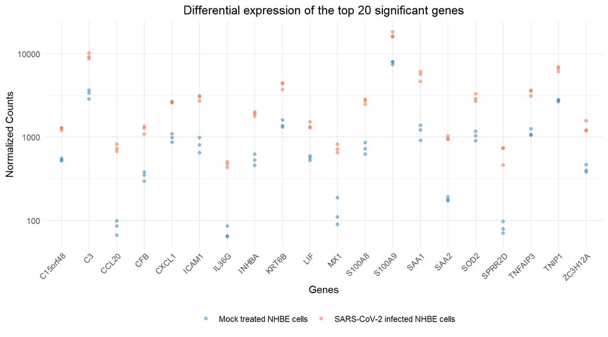

```r
# Expression plot
sig_norm_counts <- normalized_counts[NHBE_Series1_result$gene, ]

select <- sig_norm_counts[1:20,]
top_20 <- as.data.frame(select) %>%
        rownames_to_column(var = "gene")
top_20 <- gather(top_20,
                 key = "samplename",
                 value = "normalized_counts",
                 2:7)
top_20 <- inner_join(top_20,      rownames_to_column(metadata, var = "samplename"),
                     by = "samplename")

ggplot(top_20) +
        geom_point(aes(x = gene, y = normalized_counts, color = condition), alpha = 0.5) +
        scale_y_log10() +
        xlab("Genes") +
        ylab("Normalized Counts") +
        ggtitle("Differential expression of the top 20 significant genes") +
        scale_color_manual(values=c("#3288bd", "#f46d43")) +
        theme_minimal() +
        theme(axis.text.x = element_text(angle = 45, hjust = 1)) +
        theme(plot.title = element_text(hjust = 0.5), legend.position = 'bottom', legend.title = element_blank())
```

The `volcano plot` shows the log-transformed adjusted p-values plotted on the y-axis and log2 fold change values on the x-axis. This plot displays a global view of the gene expression levels.

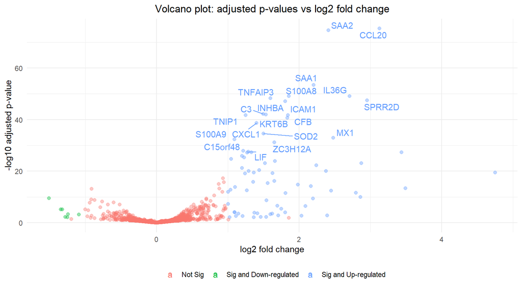

```r
# Obtain logical vector regarding whether padj values are less than 0.01 and up/down regulated genes.
dds_NHBE_Series1_result_2_p <- dds_NHBE_Series1_result_2_ %>%
              drop_na() %>%
              mutate(threshold = ifelse(padj < 0.01 & log2FoldChange >= 1, "Sig and Up-regulated", ifelse(padj < 0.01 & log2FoldChange <= -1, "Sig and Down-regulated", "Not Sig"))) %>% mutate(genelabels = "")

dds_NHBE_Series1_result_2_p <- dds_NHBE_Series1_result_2_p[order(dds_NHBE_Series1_result_2_p$padj),]
dds_NHBE_Series1_result_2_p$genelabels[1:20] <- dds_NHBE_Series1_result_2_p$gene[1:20]

ggplot(dds_NHBE_Series1_result_2_p, aes(x = log2FoldChange, y = -log10(padj), color = threshold)) +
        geom_point(alpha=0.4, size=1.75) +
        geom_text_repel(aes(label = genelabels)) +
        xlab("log2 fold change") +
        ylab("-log10 adjusted p-value") +
        theme(axis.title = element_text(size = rel(1.25))) +
        theme_minimal() +
        ggtitle("Volcano plot: adjusted p-values vs log2 fold change") +
        theme(legend.position = 'bottom', legend.title = element_blank(), plot.title = element_text(hjust = 0.5))
```

> The `volcano plot` highlighted significant differentially expressed genes down-regulated (**green**) and up-regulated (**blue**). The non-significant genes are coloured **red**.

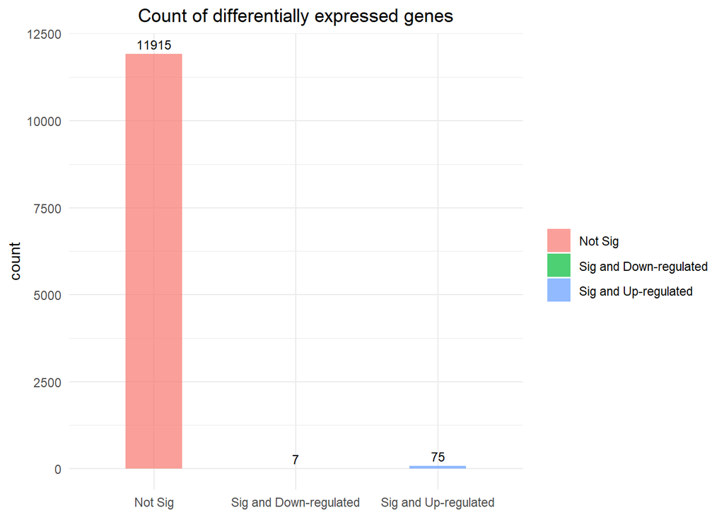

```r
count_results <- dds_NHBE_Series1_result_2_p %>%
     group_by(threshold) %>%
     summarise(count = n())

ggplot(count_results, aes(x=threshold, y=count)) +
  geom_bar(aes(fill=threshold), stat = 'identity', alpha = 0.7, width = 0.4) +
  geom_text(aes(label=count), vjust=-0.5, color="black", size=3.2) +
  ggtitle("Count of differentially expressed genes") +
  theme_minimal() +
    theme(legend.title = element_blank(), plot.title =
          element_text(hjust = 0.5), axis.title.x = element_blank())
```

> The output of RNA-seq differential expression analysis is a list of significant differentially expressed genes. In this analysis, in which was explored the differential expression in NHBE cells infected with SARS-CoV-2, **82 significant differentially expressed genes** (**7 down-regulated** and **75 up-regulated**) were identified.

#### 6.1.4. Functional Analysis

To gain greater biological insight into the list of differentially expressed genes, it is helpful to perform the functional analysis. The two commonly used enrichment methods are: Over-Representation Analysis (ORA); and Gene Set Enrichment Analysis (GSEA).

To perform the functional analysis, the Gene Ontology (GO) and Kyoto Encyclopedia of Genes and Genomes (KEGG) were used for the enrichment analysis to identify biological processes and pathways.

- Gene ontology (GO) provides a controlled vocabulary for describing biological processes, molecular functions and cellular components.
- KEGG groups genes into “pathways” representing molecular interaction and reaction networks, which are lists of genes participating in the same biological process.

##### 6.1.4.1. Over-representation analysis (ORA)

It is an approach to determine whether a known biological functions/processes are over-represented (= enriched) in a list of differentially expressed genes.

```r
GO_NHBE <- enrichGO(gene = as.character(dds_NHBE_results_sig$ensembl_gene_id),
                    universe = as.character(dds_NHBE_results$ensembl_gene_id),
                    keyType = "ENSEMBL",
                    OrgDb = org.Hs.eg.db,
                    ont = "BP",
                    pAdjustMethod = "BH",
                    pvalueCutoff = 0.01,
                    qvalueCutoff = 0.1,
                    readable = TRUE)

cluster_summary_GO <- data.frame(GO_NHBE)
nrow(cluster_summary_GO)
```

```
## [1] 351
```

```r
KEGG_NHBE <- enrichKEGG(gene=names(foldchanges_ent_sig),
                        universe=names(foldchanges_ent),
                        organism="hsa",
                        pAdjustMethod = "BH",
                        pvalueCutoff = 0.01,
                        qvalueCutoff = 0.1,
                        keyType = "ncbi-geneid")

cluster_summary_KEGG <- data.frame(KEGG_NHBE)
nrow(cluster_summary_KEGG)
```

```
## [1] 35
```

> The GO functional enrichment analysis of differentially expressed genes resulted in **351 classes**. The ID GO:0006954, for example, is a class with the description: inflammatory response.

> The KEGG functional enrichment analysis returned **35 categories**. The ID hsa04060, for example, is a category with the description: Cytokine-cytokine receptor interaction.

The `dotplot` displays the top 20 GO and KEGG biological processes with the largest gene ratios (*number of differentially expressed genes related to GO term / total number of significant differentially expressed genes*). The size of the dots represent the number of genes in the significant differentially expressed gene list associated with the GO term and the colour of the dots represent the p-adjusted values.

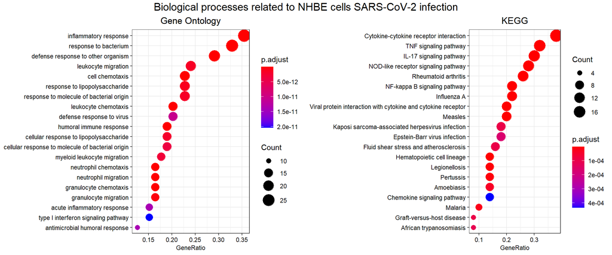

```r
p1 <- dotplot(GO_NHBE, showCategory = 20, title = "Gene Ontology", font.size = 8.5) + theme(plot.title = element_text(hjust = 0.5))

p2 <- dotplot(KEGG_NHBE,
        showCategory = 20,
        title = "KEGG",
        font.size = 8.5) + theme(plot.title = element_text(hjust = 0.5))

grid.arrange(p1, p2, ncol=2, top = textGrob("Biological processes related to NHBE cells SARS-CoV-2 infection", gp=gpar(fontsize=15)))
```

The `heatplot` shows the GO functional enrichment analysis of differentially expressed genes. The colour of the squares represents the fold change values.

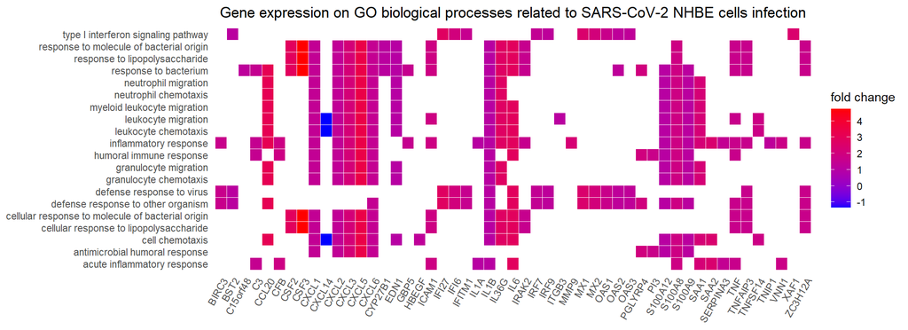

```r
heatplot(GO_NHBE, foldChange=foldchanges_gene_sig,showCategory = 20) + ggtitle("Gene expression on GO biological processes related to SARS-CoV-2 NHBE cells infection") + theme(plot.title = element_text(hjust = 0.5))
```

The `enrichment plot` shows the relationship between the significantly enriched GO terms by grouping similar terms together. The colour represents the p-adjusted values and the size of the terms represents the number of genes identified that are significant.

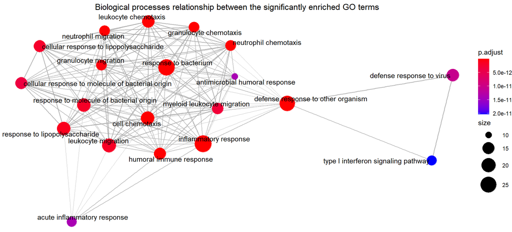

```r
emapplot(GO_NHBE, showCategory = 20, pie_scale=1.5,layout="kk", line_scale = 0.3) + ggtitle("Biological processes relationship between the significantly enriched GO terms") + theme(plot.title = element_text(hjust = 0.5))
```

The `KEGG pathway map` is a molecular interaction/reaction network diagram represented in terms of the KEGG orthology groups. The enriched KEGG pathway `hsa04060 - Cytokine-cytokine receptor interaction`, for example, contains **19** significant differentially expressed gene.

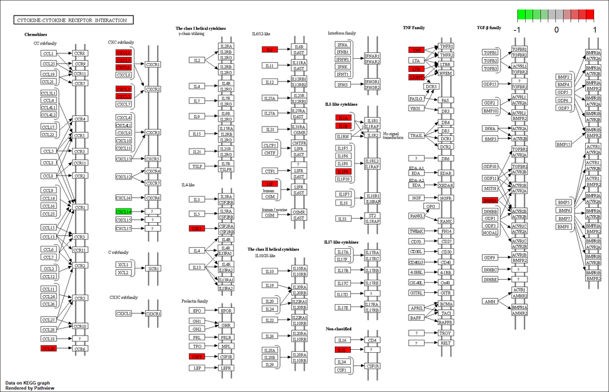

```r
# Produce the native KEGG plot (PNG)
KEGG_pathway <- pathview(gene.data=foldchanges_ent_sig, pathway.id="hsa04060", species = "hsa")

knitr::include_graphics("hsa04060.pathview.png")
```

The **red** coloured boxes are up-regulated/activated genes. On the other hand, the **green** ones are down-regulated/suppressed genes.

##### 6.1.4.2. Gene Set Enrichment Analysis (GSEA):

The GSEA aggregates the per gene statistics or log2 fold changes across genes within a gene set, then looks to see whether gene sets for particular biological pathways are enriched among the large positive or negative fold changes.

```r
gse_GO_NHBE <- gseGO(geneList = foldchanges_gene,
              minGSSize = 3,
              maxGSSize    = 800,
              pvalueCutoff = 0.01,
              pAdjustMethod = "none",
              keyType       = "ENSEMBL",
              ont ="BP",
              verbose = TRUE,
              OrgDb = org.Hs.eg.db)

gse_KEGG_NHBE <- gseKEGG(geneList = foldchanges_ent,
              organism = "hsa",
              minGSSize = 3,
              maxGSSize    = 800,
              pvalueCutoff = 0.01,
              pAdjustMethod = "none",
              keyType       = "ncbi-geneid")
```

The `dotplots` below displays biological processes through gene set enrichment analysis (GSEA) related to NHBE cells SARS-CoV-2 infected.

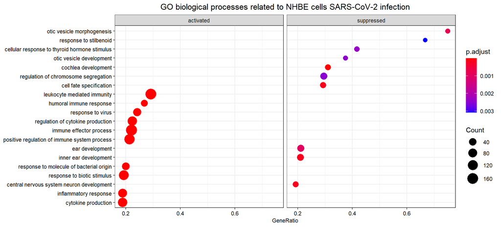

```r
dotplot(gse_GO_NHBE, showCategory= 10, title = "GO biological processes related to NHBE cells SARS-CoV-2 infection", font.size = 8.5, split=".sign") + facet_grid(.~.sign) + theme(plot.title = element_text(hjust = 0.5))
```

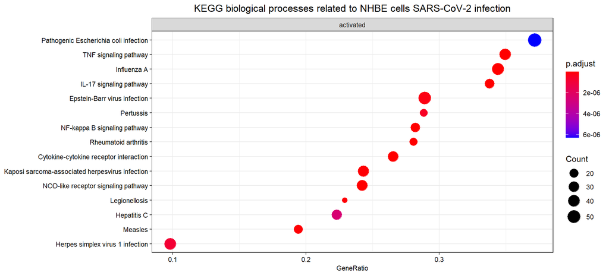

```r
dotplot(gse_KEGG_NHBE, showCategory = 15, title = "KEGG biological processes related to NHBE cells SARS-CoV-2 infection", font.size = 8.5, split=".sign") + facet_grid(.~.sign) + theme(plot.title = element_text(hjust = 0.5))
```

### **6.2. Lung biopsy sample from *post mortem* COVID-19 patient**

```r
# Building the DESeq2 object
remove.list <- paste(c("NHBE"), collapse = '|')
metadata <- metadata[c(8, 7, 10, 9),]
dds_lung_Series15 <- DESeqDataSetFromMatrix(countData = data_raw[, !grepl(remove.list, colnames(data_raw))],
                              colData = metadata[!grepl(remove.list, metadata$type),],
                              design = ~ condition)


head(counts(dds_lung_Series15))
```

```
##           Series15_HealthyLungBiopsy_2 Series15_HealthyLungBiopsy_1
## DDX11L1                              0                            0
## WASH7P                             261                          140
## FAM138A                              0                            0
## FAM138F                              0                            0
## OR4F5                                0                            0
## LOC729737                           15                           70
##           Series15_COVID19Lung_2 Series15_COVID19Lung_1
## DDX11L1                        0                      0
## WASH7P                         0                      0
## FAM138A                        0                      0
## FAM138F                        0                      0
## OR4F5                          0                      0
## LOC729737                     17                      0
```

#### 6.2.1. Quality assessment

This procedure checks the count data to ensure that the samples/replicates look good. For this purpose, hierarchical clustering (HC) and principal component analysis (PCA) methods were applied.

```r
dds <- estimateSizeFactors(dds_lung_Series15)
#sizeFactors(dds)

normalized_counts <- counts(dds, normalized=TRUE)
```

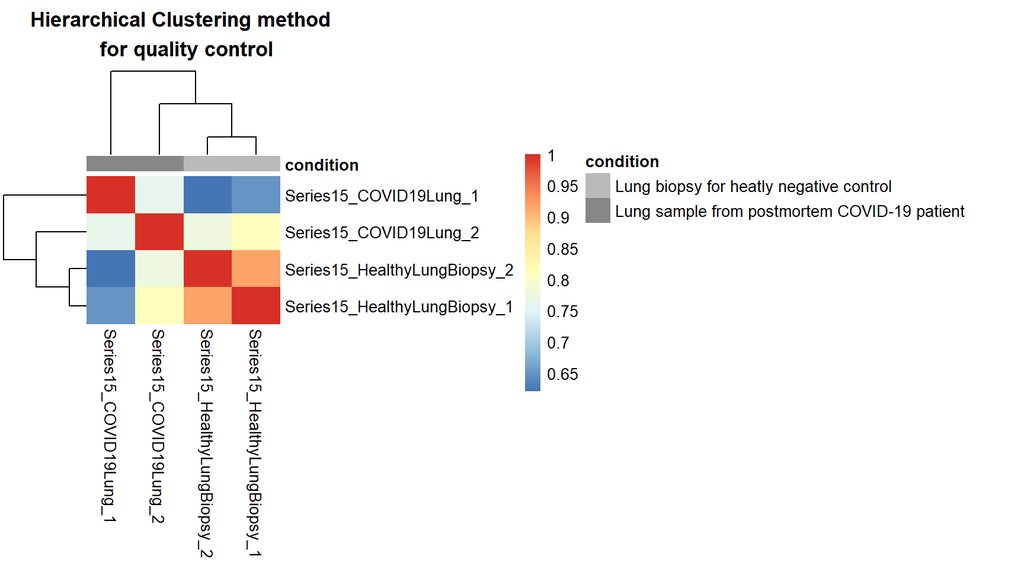

```r
dds_log <- vst(dds, blind=TRUE)
dds_log_matrix <- assay(dds_log) # Matrix

vsd_corr <- cor(dds_log_matrix)

ann_colors = list(condition = c("Lung biopsy for heatly negative control" = "#bababa", "Lung sample from postmortem COVID-19 patient" = "#878787"))

metadata_n <- metadata

pheatmap(vsd_corr,
         annotation = select(metadata_n, condition),
         annotation_colors = ann_colors,
         annotation_legend = TRUE,
         main = "Hierarchical Clustering method \n for quality control")
```

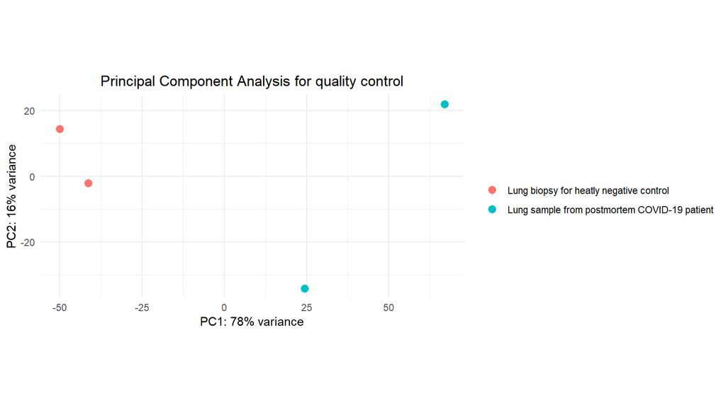

```r
plotPCA(dds_log, intgroup = "condition") +
  theme_minimal() +
  ggtitle("Principal Component Analysis for quality control") +
  theme(plot.title = element_text(hjust = 0.5), legend.title = element_blank())
```

- The PC1 explains the most variation in the data (78% of variance). The healthy negative control cluster and COVID-19 lung “cluster” are separated on PC1. It seems that a lot of variation in gene expression can be explained by conditions (healthy vs COVID-19 patients).

> Together, **these quality controls suggest that the data are of regular quality**.

#### 6.2.2. Running DESeq2 - differential expression analysis

```r
dds_lung_Series15 <- DESeq(dds_lung_Series15)
```

The function `DESeq()` performed the following procedures:  
- estimating size factors  
- estimating dispersions  
- gene-wise dispersion estimates  
- mean-dispersion relationship  
- final dispersion estimates  
- fitting model and testing

`DESeq2` model uses estimated dispersion to assess the variability in expression when modelling the counts. Each black dot represents a gene. Genes with low dispersion estimates are shrunken towards the curve.

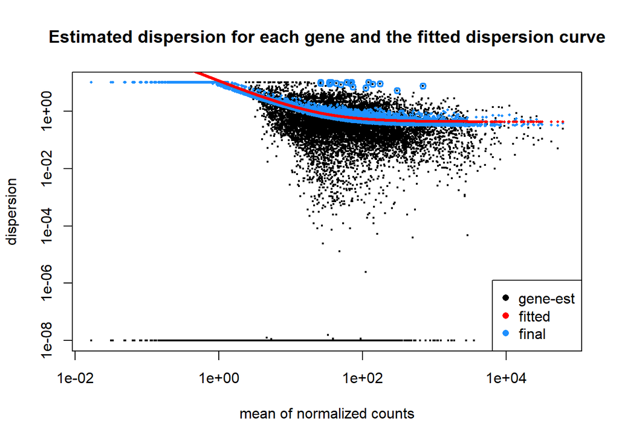

```r
plotDispEsts(dds_lung_Series15, main = "Estimated dispersion for each gene and the fitted dispersion curve")
```

> The dispersion in gene expression decreases with increasing mean. The fit of the data to the model is good since the dispersions decrease with increasing mean and cluster around the maximum likelihood (ML) line. It’s expected that the data scatter around the curve, with the dispersion decreasing with increasing mean expression levels.

$$↑variation ⇒ ↑dispersion$$
$$↑mean ⇒ ↓dispersion$$

As already commented, `DESeq2` uses a negative binomial distribution to model the RNA-seq counts, and the coefficients are the estimates for the log2 foldchanges for each sample group. **To generate more accurate log2 foldchange estimates (effect size), the `DESeq2` authors recommend “shrinking” the log fold-changes which is available in `DESeq2’s` `lfcShrink` function**. The unshrunken results (1) and shrunken results (2) were performed.

```r
dds_lung_Series15_result_1 <- results(dds_lung_Series15,
            contrast = c("condition", "Lung sample from postmortem COVID-19 patient", "Lung biopsy for heatly negative control"),
            alpha = 0.01)

dds_lung_Series15_result_2 <- lfcShrink(dds_lung_Series15,
            coef= "condition_Lung.sample.from.postmortem.COVID.19.patient_vs_Lung.biopsy.for.heatly.negative.control",
            type="apeglm")
```

The `MA plot` can be useful to explore the results. The log2 fold change is plotted on the y-axis, the average of the counts normalized by size factor is shown on the x-axis. Each gene is represented with a dot, and the genes that are significantly differentially expressed are coloured **blue**.

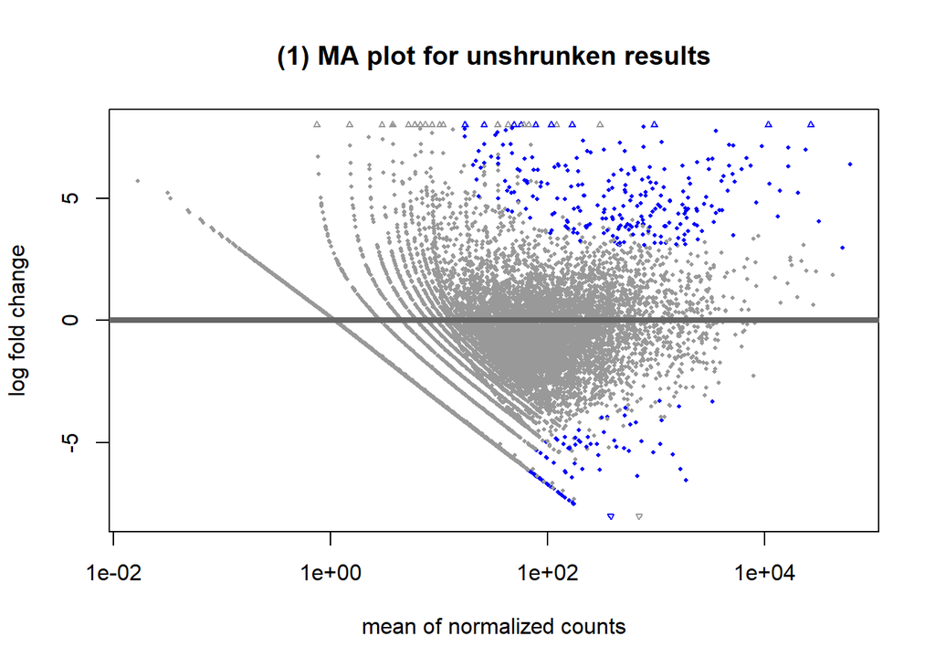

```r
# The MA plot shows the mean of normalized count versus the log2 fold changes for all genes tested.
plotMA(dds_lung_Series15_result_1, ylim=c(-8,8), main = "(1) MA plot for unshrunken results")
```

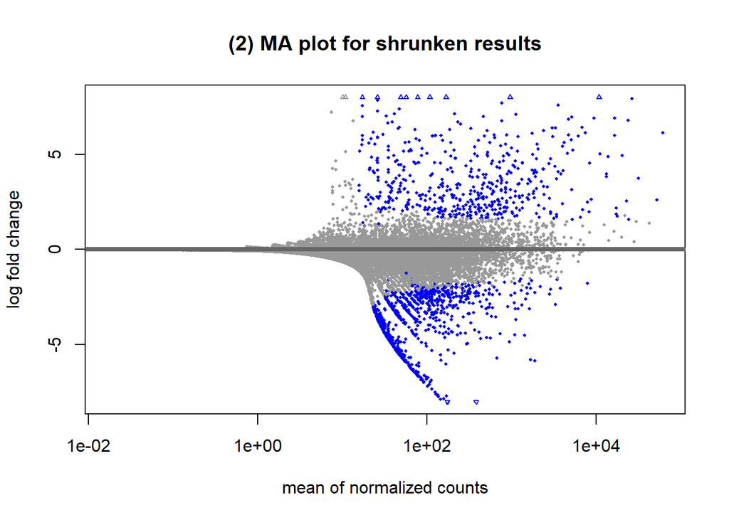

```r
plotMA(dds_lung_Series15_result_2, ylim=c(-8,8), main = "(2) MA plot for shrunken results")
```

`MA plots` often display a fanning-effect at the left-hand side (genes with low numbers of counts) due to the high variability of the measurements for these genes. These plots demonstrate that only genes with a large average normalized count contain sufficient information to yield a significant call.

> **The shrunken results (second plot) were more stable fold change values**. So, the shrunken results were used.

#### 6.2.3. Results

```r
head(dds_lung_Series15_result_2)
```

```
## log2 fold change (MAP): condition Lung.sample.from.postmortem.COVID.19.patient vs Lung.biopsy.for.heatly.negative.control
## Wald test p-value: condition Lung.sample.from.postmortem.COVID.19.patient vs Lung.biopsy.for.heatly.negative.control
## DataFrame with 6 rows and 5 columns
##            baseMean log2FoldChange     lfcSE    pvalue      padj
##           <numeric>      <numeric> <numeric> <numeric> <numeric>
## DDX11L1      0.0000             NA        NA        NA        NA
## WASH7P      10.6440      -0.652445   1.25722 0.1169537        NA
## FAM138A      0.0000             NA        NA        NA        NA
## FAM138F      0.0000             NA        NA        NA        NA
## OR4F5        0.0000             NA        NA        NA        NA
## LOC729737   14.3177       1.374500   1.78164 0.0466317        NA
```

- **baseMean:** average of the normalized count values, divided by size factors, taken over all samples.
- **log2FoldChange:** the effect size estimated, which is a measure describing how much the gene’s expression is different between control and infected groups. This value is reported as base 2 logarithmic scale. A log2 fold change of 1 ($\log2(FC) = 1$) means that the gene’s expression is increased by a multiplicative factor of $2^1 = 2$.
- **lfcSE:** standard error estimated for the log2 fold change estimated.
- **pvalue:** Wald test p-value for $p < 0.01$.
- **padj:** false discovery rate (FDR)/Benjamini-Hochberg (BH) adjusted p-values, to control the false positives.

```r
summary(dds_lung_Series15_result_2)
```

```
##
## out of 18281 with nonzero total read count
## adjusted p-value < 0.1
## LFC > 0 (up)       : 505, 2.8%
## LFC < 0 (down)     : 891, 4.9%
## outliers [1]       : 0, 0%
## low counts [2]     : 8771, 48%
## (mean count < 15)
## [1] see 'cooksCutoff' argument of ?results
## [2] see 'independentFiltering' argument of ?results
```

> The result was **1396 (sum of LFC: log2 fold changes) genes with differential expression** of a total of 18281 with non-zero total read count. This summary represents the number of genes that are considered up- and down-regulated according to the Wald test.

Using any cut-off (padj and/or threshold values) can be helpful when dealing with large numbers of differentially expressed genes. However, it increases the risk of losing biologically relevant gene.

- By specifying a threshold equal to 1 for log2 fold change values ($\log2(FC) = 1$), then $foldchange = 2^1$ between infected and control groups for gene counts. The infected group count is twice as big as control (infected is 200% of control).
- If ($\log2(FC) = -1$), then $Fold Change = 2^{-1}$ between infected and control groups for gene counts. The infected group count is half as big as control (infected is 50% of control).

```r
dds_lung_Series15_result_2_ <- dds_lung_Series15_result_2 %>%
  data.frame() %>%
  rownames_to_column(var="gene")

dds_lung_Series15_result_2_sig <- dds_lung_Series15_result_2_ %>%
        filter(padj < 0.01 & abs(log2FoldChange) > 1)

nrow(dds_lung_Series15_result_2_sig)
```

```
## [1] 342
```

> After applying the cut-offs $padj < 0.01$ & $abs(log2FoldChange) > 1$, **the number of significant differentially expressed genes was 342.**

```r
dds_lung_Series15_result <- dds_lung_Series15_result_2_sig[order(dds_lung_Series15_result_2_sig$padj),]
rownames(dds_lung_Series15_result) <- NULL
as.datatable(formattable(dds_lung_Series15_result,
                         list(
                           log2FoldChange = color_tile("#ffffff", "#6baed6"),
                           padj = color_tile("#74c476", "#e5f5e0"),
                           `gene` = formatter(
              "span", style = ~ style(color = "grey",font.weight = "bold")))))
```

|  | gene | baseMean | log2FoldChange | lfcSE | pvalue | padj |
| --- | --- | --- | --- | --- | --- | --- |
| 1 | SELL | 10726.92516 | 8.614989 | 0.9093265 | 1.427926e-22 | 1.357958e-18 |
| 2 | CLEC4E | 3558.53955 | 7.596430 | 0.8238994 | 1.640394e-21 | 7.800074e-18 |
| 3 | ST20 | 958.24272 | 8.114336 | 0.8930281 | 6.220616e-21 | 1.971935e-17 |
| 4 | IFI6 | 16371.46537 | 6.902123 | 0.8082390 | 7.128113e-19 | 1.694709e-15 |
| 5 | FFAR2 | 1122.52640 | 7.107316 | 0.8471013 | 2.724069e-18 | 5.181179e-15 |
| 6 | FDCSP | 168.08550 | 11.168593 | 1.2928401 | 5.610788e-18 | 8.893100e-15 |
| 7 | FCER1G | 23554.69839 | 6.790349 | 0.8546071 | 1.124446e-16 | 1.527641e-13 |
| 8 | CCL8 | 5087.56802 | 6.963767 | 0.8793872 | 1.348096e-16 | 1.602549e-13 |
| 9 | P2RY13 | 763.93060 | 7.687050 | 0.9922797 | 4.192417e-16 | 4.429987e-13 |
| 10 | STAP1 | 212.24852 | 7.130465 | 0.9332554 | 1.498764e-15 | 1.425324e-12 |

[output cut: 332 more lines]

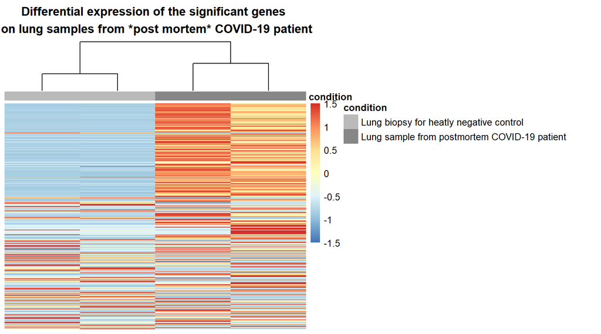

```r
sig_norm_counts <- normalized_counts[dds_lung_Series15_result$gene, ]

select <- sig_norm_counts[1:342,]

ann_colors = list(condition = c("Lung biopsy for heatly negative control" = "#bababa", "Lung sample from postmortem COVID-19 patient" = "#878787"))
pheatmap(select,
         cluster_rows = FALSE,
         show_rownames = FALSE,
         show_colnames = FALSE,
         border_color = NA,
         annotation = select(metadata, condition),
         annotation_colors = ann_colors,
         scale = "row",
         main = "Differential expression of the significant genes \n on lung samples from *post mortem* COVID-19 patient")
```

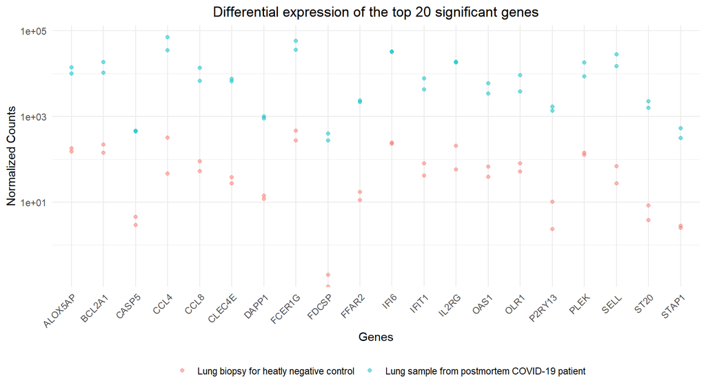

```r
# Expression plot
sig_norm_counts <- normalized_counts[dds_lung_Series15_result$gene, ]

select <- sig_norm_counts[1:20,]
top_20 <- as.data.frame(select) %>%
        rownames_to_column(var = "gene")
top_20 <- gather(top_20,
                 key = "samplename",
                 value = "normalized_counts",
                 2:5)
top_20 <- inner_join(top_20,      rownames_to_column(metadata, var = "samplename"),
                     by = "samplename")

ggplot(top_20) +
        geom_point(aes(x = gene, y = normalized_counts, color = condition), alpha = 0.5) +
        scale_y_log10() +
        xlab("Genes") +
        ylab("Normalized Counts") +
        ggtitle("Differential expression of the top 20 significant genes") +
        theme_minimal() +
        theme(axis.text.x = element_text(angle = 45, hjust = 1)) +
        theme(plot.title = element_text(hjust = 0.5), legend.position = 'bottom', legend.title = element_blank())
```

The `volcano plot` shows the log-transformed adjusted p-values plotted on the y-axis and log2 fold change values on the x-axis. This plot displays a global view of the gene expression levels.

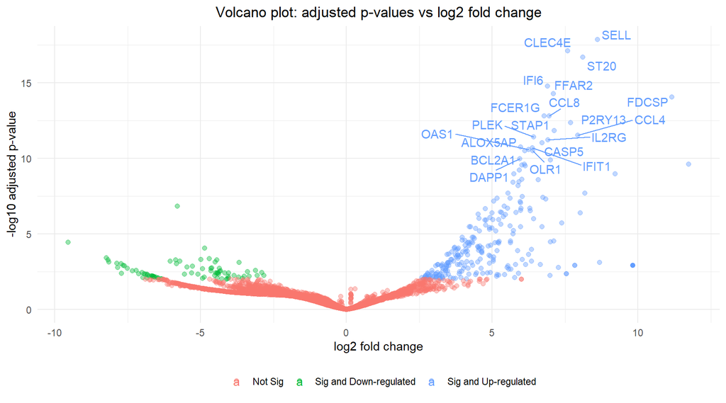

```r
# Obtain logical vector regarding whether padj values are less than 0.01 and up/down regulated genes.
dds_lung_Series15_result_2_p <- dds_lung_Series15_result_2_ %>%
              drop_na() %>%
              mutate(threshold = ifelse(padj < 0.01 & log2FoldChange > 1, "Sig and Up-regulated", ifelse(padj < 0.01 & log2FoldChange < -1, "Sig and Down-regulated", "Not Sig"))) %>% mutate(genelabels = "")

dds_lung_Series15_result_2_p <- dds_lung_Series15_result_2_p[order(dds_lung_Series15_result_2_p$padj),]
dds_lung_Series15_result_2_p$genelabels[1:20] <- dds_lung_Series15_result_2_p$gene[1:20]

ggplot(dds_lung_Series15_result_2_p, aes(x = log2FoldChange, y = -log10(padj), color = threshold)) +
        geom_point(alpha=0.4, size=1.75) +
        geom_text_repel(aes(label = genelabels)) +
        xlab("log2 fold change") +
        ylab("-log10 adjusted p-value") +
        theme(axis.title = element_text(size = rel(1.25))) +
        theme_minimal() +
        ggtitle("Volcano plot: adjusted p-values vs log2 fold change") +
        theme(legend.position = 'bottom', legend.title = element_blank(), plot.title = element_text(hjust = 0.5))
```

> The `volcano plot` highlighted significant differentially expressed genes down-regulated (**green**) and up-regulated (**blue**). The non-significant genes are colored **red**.

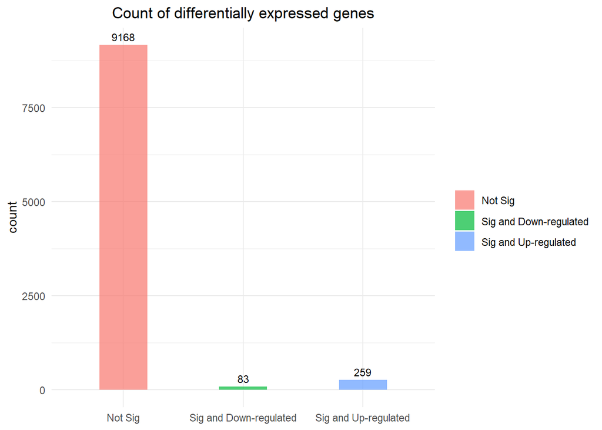

```r
count_results <- dds_lung_Series15_result_2_p %>%
     group_by(threshold) %>%
     summarise(count = n())

ggplot(count_results, aes(x=threshold, y=count)) +
  geom_bar(aes(fill=threshold), stat = 'identity', alpha = 0.7, width = 0.4) +
  geom_text(aes(label=count), vjust=-0.5, color="black", size=3.2) +
  ggtitle("Count of differentially expressed genes") +
  theme_minimal() +
    theme(legend.title = element_blank(), plot.title =
          element_text(hjust = 0.5), axis.title.x = element_blank())
```

> The output of RNA-seq differential expression analysis is a list of significant differentially expressed genes. In this analysis, in which was explored the differential expression in lung biopsy sample from *post mortem* COVID-19 patient, **342 significant differentially expressed genes** (**83 down-regulated** and **259 up-regulated**) were identified.

#### 6.2.4. Functional Analysis

To gain greater biological insight into the list of differentially expressed genes, it is helpful to perform functional analysis. The two commonly used enrichment methods are: Over-Representation Analysis (ORA); and Gene Set Enrichment Analysis (GSEA).

To perform the functional analysis the Gene Ontology (GO) and Kyoto Encyclopedia of Genes and Genomes (KEGG) were used for the enrichment analysis with the objective to identify biological processes and pathways.

- Gene ontology (GO) provides a controlled vocabulary for describing biological processes, molecular functions and cellular components.
- KEGG groups genes into “pathways” representing molecular interaction and reaction networks, which are basically lists of genes participating in the same biological process.

##### 6.2.4.1. Over-representation analysis (ORA)

It is an approach to determine whether a known biological functions/processes are over-represented (= enriched) in a list of differentially expressed genes.

```r
GO_lung <- enrichGO(gene = as.character(dds_lung_results_sig$ensembl_gene_id),
                    universe = as.character(dds_lung_results$ensembl_gene_id),
                    keyType = "ENSEMBL",
                    OrgDb = org.Hs.eg.db,
                    ont = "BP",
                    pAdjustMethod = "BH",
                    pvalueCutoff = 0.01,
                    qvalueCutoff = 0.1,
                    readable = TRUE)

cluster_summary_GO_lung <- data.frame(GO_lung)
nrow(cluster_summary_GO_lung)
```

```
## [1] 184
```

```r
KEGG_lung <- enrichKEGG(gene=names(foldchanges_ent_sig),
                        universe=names(foldchanges_ent),
                        organism="hsa",
                        pAdjustMethod = "BH",
                        pvalueCutoff = 0.01,
                        qvalueCutoff = 0.1,
                        keyType = "ncbi-geneid")

cluster_summary_KEGG_lung <- data.frame(KEGG_lung)
nrow(cluster_summary_KEGG_lung)
```

```
## [1] 6
```

> The GO functional enrichment analysis of differentially expressed genes returned **184 classes**. The ID GO:0098542, for example, is a class with the description: defense response to other organism.

> The KEGG functional enrichment analysis returned **6 categories**. The ID hsa04060, for example, is a category with the description: Cytokine-cytokine receptor interaction.

The `dotplot` displays the top 20 GO and KEGG biological processes with the largest gene ratios (*number of differentially expressed genes related to GO term / total number of significant differentially expressed genes*). The size of the dots represent the number of genes in the significant differentially expressed gene list associated with the GO term and the colour of the dots represent the p-adjusted values.

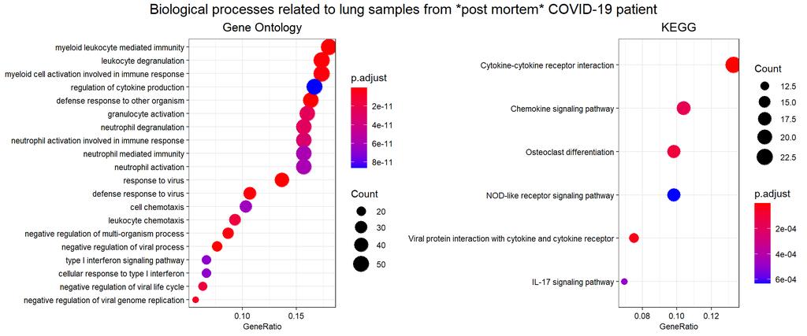

```r
p1 <- dotplot(GO_lung, showCategory = 20, title = "Gene Ontology", font.size = 8.5) + theme(plot.title = element_text(hjust = 0.5))

p2 <- dotplot(KEGG_lung,
        showCategory = 20,
        title = "KEGG",
        font.size = 8.5) + theme(plot.title = element_text(hjust = 0.5))

grid.arrange(p1, p2, ncol=2, top = textGrob("Biological processes related to lung samples from *post mortem* COVID-19 patient", gp=gpar(fontsize=15)))
```

The `heatplot` shows the GO functional enrichment analysis of differentially expressed genes. The colour of the squares represents the fold change values.

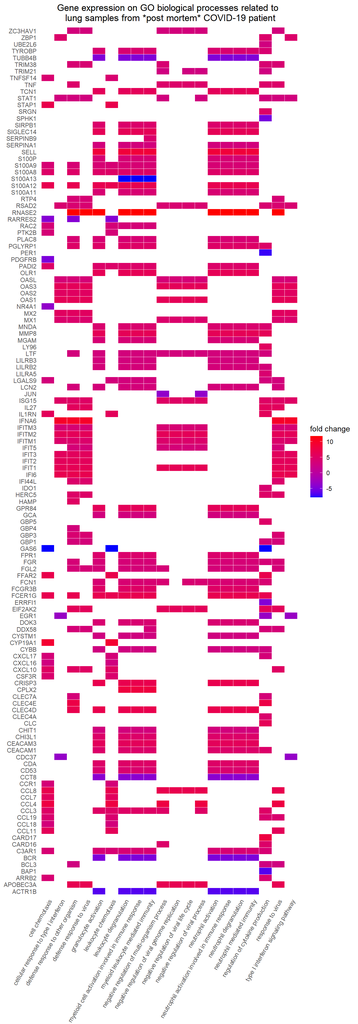

```r
heatplot(GO_lung, foldChange=foldchanges_gene_sig, showCategory = 20) + ggtitle("Gene expression on GO biological processes related to \n lung samples from *post mortem* COVID-19 patient") + theme(plot.title = element_text(hjust = 0.5)) + coord_flip()
```

The `enrichment plot` shows the relationship between the significantly enriched GO terms by grouping similar terms together. The colour represents the p-adjusted values and the size of the terms represents the number of genes identified that are significant.

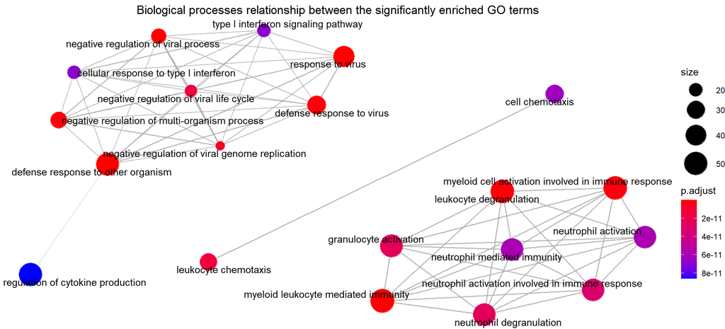

```r
emapplot(GO_lung, showCategory = 20, pie_scale=1.5,layout="kk", line_scale = 0.3) + ggtitle("Biological processes relationship between the significantly enriched GO terms") + theme(plot.title = element_text(hjust = 0.5))
```

The `KEGG pathway map` is a molecular interaction/reaction network diagram represented in terms of the KEGG orthology groups. The enriched KEGG pathway `hsa04061 - Viral protein interaction with cytokine and cytokine receptor`, for example, contains **13** significant differentially expressed gene.

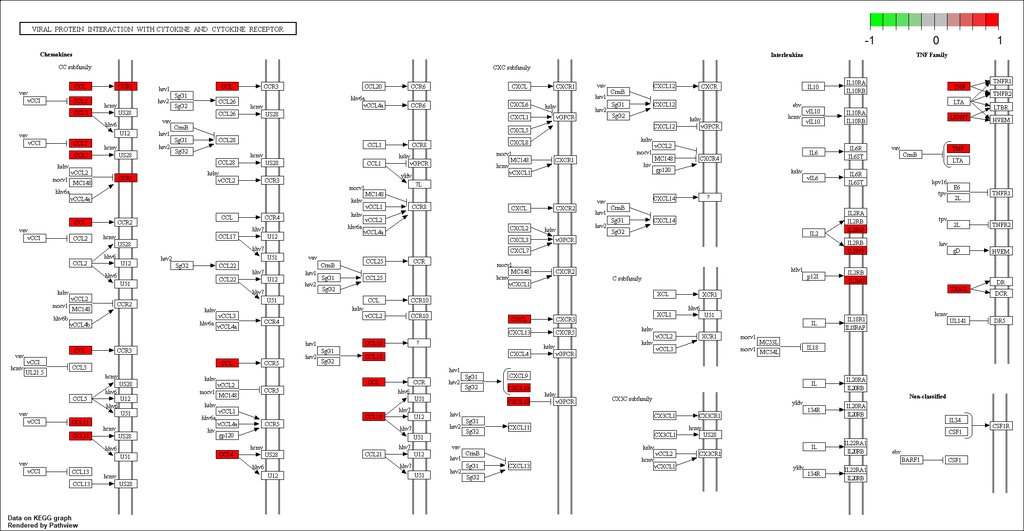

```r
# Produce the native KEGG plot (PNG)
KEGG_pathway <- pathview(gene.data=foldchanges_ent_sig, pathway.id="hsa04061", species = "hsa")

knitr::include_graphics("hsa04061.pathview.png")
```

The **red** colored boxes are up-regulated/activated genes. On the other hand, the **green** ones are down-regulated/suppressed genes.

##### 6.2.4.2. Gene Set Enrichment Analysis (GSEA):

The GSEA aggregates the per gene statistics or log2 fold changes across genes within a gene set, then looks to see whether gene sets for particular biological pathways are enriched among the large positive or negative fold changes.

```r
gse_GO_lung <- gseGO(geneList = foldchanges_gene,
              minGSSize = 3,
              maxGSSize    = 800,
              pvalueCutoff = 0.01,
              pAdjustMethod = "none",
              keyType       = "ENSEMBL",
              ont ="BP",
              verbose = TRUE,
              OrgDb = org.Hs.eg.db)

gse_KEGG_lung <- gseKEGG(geneList = foldchanges_ent,
              organism = "hsa",
              minGSSize = 3,
              maxGSSize    = 800,
              pvalueCutoff = 0.01,
              pAdjustMethod = "none",
              keyType       = "ncbi-geneid")
```

The `dotplots` below displays biological processes through gene set enrichment analysis (GSEA) related to lung samples from *post mortem* COVID-19 patient.

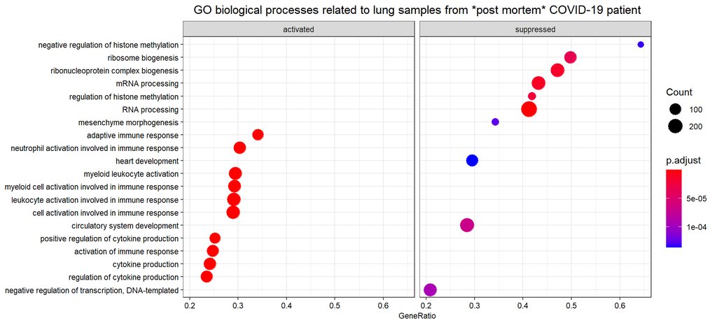

```r
dotplot(gse_GO_lung, showCategory= 10, title = "GO biological processes related to lung samples from *post mortem* COVID-19 patient", font.size = 8.5, split=".sign") + facet_grid(.~.sign) + theme(plot.title = element_text(hjust = 0.5))
```

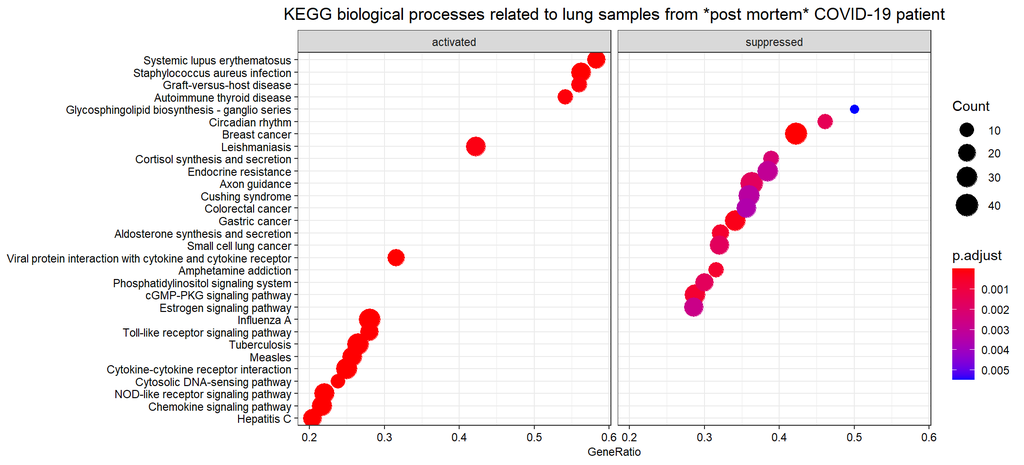

```r
dotplot(gse_KEGG_lung, showCategory = 15, title = "KEGG biological processes related to lung samples from *post mortem* COVID-19 patient", font.size = 8.5, split=".sign") + facet_grid(.~.sign) + theme(plot.title = element_text(hjust = 0.5))
```

## 7. Comparing NHBE cells and lung biopsy samples results

The top 6 GO functional enrichment analysis of differentially expressed genes of NHBE cells infected with SARS-CoV-2 and lung biopsy samples from *post mortem* COVID-19 patient were compared.

```r
bind_GO <- cbind(cluster_summary_GO[1:6,1:2], cluster_summary_GO_lung[1:6,1:2])
rownames(bind_GO) <- NULL
colnames(bind_GO) <- c("ID.NHBE", "Description.NHBE", "ID.Lung", "Description.Lung")
bind_GO
```

```
##      ID.NHBE                   Description.NHBE    ID.Lung
## 1 GO:0009617              response to bacterium GO:0098542
## 2 GO:0006954              inflammatory response GO:0009615
## 3 GO:0098542 defense response to other organism GO:0048525
## 4 GO:0030593              neutrophil chemotaxis GO:0002444
## 5 GO:0060326                    cell chemotaxis GO:0043299
## 6 GO:0006959            humoral immune response GO:0051607
##                       Description.Lung
## 1   defense response to other organism
## 2                    response to virus
## 3 negative regulation of viral process
## 4  myeloid leukocyte mediated immunity
## 5              leukocyte degranulation
## 6            defense response to virus
```

```r
formattable(bind_GO, list(area(row = 3, col = 1:2) ~ color_tile("#80b1d3", "#80b1d3"),
            area(row = 1, col = 3:4) ~ color_tile("#80b1d3", "#80b1d3")))
```

| ID.NHBE | Description.NHBE | ID.Lung | Description.Lung |
| --- | --- | --- | --- |
| GO:0009617 | response to bacterium | GO:0098542 | defense response to other organism |
| GO:0006954 | inflammatory response | GO:0009615 | response to virus |
| GO:0098542 | defense response to other organism | GO:0048525 | negative regulation of viral process |
| GO:0030593 | neutrophil chemotaxis | GO:0002444 | myeloid leukocyte mediated immunity |
| GO:0060326 | cell chemotaxis | GO:0043299 | leukocyte degranulation |
| GO:0006959 | humoral immune response | GO:0051607 | defense response to virus |

```r
bind_KEGG <- cbind(cluster_summary_KEGG[1:6,1:2],
cluster_summary_KEGG_lung[1:6,1:2])
rownames(bind_KEGG) <- NULL
colnames(bind_KEGG) <- c("ID.NHBE", "Description.NHBE", "ID.Lung", "Description.Lung")
bind_KEGG
```

```
##    ID.NHBE                                              Description.NHBE
## 1 hsa04060                        Cytokine-cytokine receptor interaction
## 2 hsa04657                                       IL-17 signaling pathway
## 3 hsa04668                                         TNF signaling pathway
## 4 hsa05323                                          Rheumatoid arthritis
## 5 hsa04061 Viral protein interaction with cytokine and cytokine receptor
## 6 hsa04621                           NOD-like receptor signaling pathway
##    ID.Lung                                              Description.Lung
## 1 hsa04060                        Cytokine-cytokine receptor interaction
## 2 hsa04061 Viral protein interaction with cytokine and cytokine receptor
## 3 hsa04380                                    Osteoclast differentiation
## 4 hsa04062                                   Chemokine signaling pathway
## 5 hsa04657                                       IL-17 signaling pathway
## 6 hsa04621                           NOD-like receptor signaling pathway
```

```r
formattable(bind_KEGG, list(area(row = 1, col = 1:4) ~ color_tile("#7fc97f", "#7fc97f"),
            area(row = 2, col = 1:2) ~ color_tile("#beaed4", "#beaed4"),
            area(row = 5, col = 3:4) ~ color_tile("#beaed4", "#beaed4"),
            area(row = 5, col = 1:2) ~ color_tile("#fdc086", "#fdc086"),
            area(row = 2, col = 3:4) ~ color_tile("#fdc086", "#fdc086"),
            area(row = 6, col = 1:4) ~ color_tile("#ffff99", "#ffff99")))
```

| ID.NHBE | Description.NHBE | ID.Lung | Description.Lung |
| --- | --- | --- | --- |
| hsa04060 | Cytokine-cytokine receptor interaction | hsa04060 | Cytokine-cytokine receptor interaction |
| hsa04657 | IL-17 signaling pathway | hsa04061 | Viral protein interaction with cytokine and cytokine receptor |
| hsa04668 | TNF signaling pathway | hsa04380 | Osteoclast differentiation |
| hsa05323 | Rheumatoid arthritis | hsa04062 | Chemokine signaling pathway |
| hsa04061 | Viral protein interaction with cytokine and cytokine receptor | hsa04657 | IL-17 signaling pathway |
| hsa04621 | NOD-like receptor signaling pathway | hsa04621 | NOD-like receptor signaling pathway |

Finally, **the common significant differentially expressed genes** between NHBE cells infected with SARS-CoV-2 and lung biopsy sample from *post mortem* COVID-19 patient were analysed.

```r
NHBEvslung_gene <- inner_join(dds_NHBE_results_sig, dds_lung_results_sig, suffix = c(".NHBE", ".lung"), by="gene")
NHBEvslung_gene_sub <- NHBEvslung_gene[, c(1, 3, 6, 11, 14, 17)]
NHBEvslung_gene_sub$description.lung <- gsub(" \\[.*","",NHBEvslung_gene_sub$description.lung)
colnames(NHBEvslung_gene_sub)[6] <- "description"

formattable(NHBEvslung_gene_sub,
                         list(
                           log2FoldChange.NHBE = color_tile("#e0f3f8", "#4575b4"),
                           padj.NHBE = color_tile("#8073ac", "#d8daeb"),
                           log2FoldChange.lung = color_tile("#e0f3f8", "#4575b4"),
                           padj.lung = color_tile("#e08214", "#fee0b6"),
                           `gene` = formatter(
              "span", style = ~ style(color = "grey",font.weight = "bold"))))
```

| gene | log2FoldChange.NHBE | padj.NHBE | log2FoldChange.lung | padj.lung | description |
| --- | --- | --- | --- | --- | --- |
| IFI6 | 2.032965 | 2.024742e-03 | 6.902123 | 1.694709e-15 | interferon alpha inducible protein 6 |
| GBP5 | 1.537908 | 6.035089e-03 | 4.953489 | 5.764969e-05 | guanylate binding protein 5 |
| S100A9 | 1.093623 | 4.160443e-33 | 3.822685 | 1.099217e-03 | S100 calcium binding protein A9 |
| S100A12 | 1.025320 | 8.093914e-03 | 6.839176 | 5.036484e-08 | S100 calcium binding protein A12 |
| S100A8 | 1.853742 | 6.994744e-50 | 4.874955 | 6.472766e-05 | S100 calcium binding protein A8 |
| IFITM1 | 1.543041 | 2.136682e-09 | 4.546268 | 9.738858e-07 | interferon induced transmembrane protein 1 |
| RND1 | 1.371710 | 1.593486e-04 | -3.328707 | 6.269015e-03 | Rho family GTPase 1 |
| OAS1 | 1.653108 | 7.679532e-17 | 6.247918 | 2.695696e-11 | 2’-5’-oligoadenylate synthetase 1 |
| OAS3 | 1.291336 | 1.031821e-20 | 6.030841 | 3.482657e-08 | 2’-5’-oligoadenylate synthetase 3 |
| OAS2 | 1.239521 | 8.977843e-20 | 5.410857 | 1.435944e-07 | 2’-5’-oligoadenylate synthetase 2 |
| C15orf48 | 1.218023 | 1.323613e-28 | 3.675962 | 8.901122e-03 | chromosome 15 open reading frame 48 |
| BCL2A1 | 2.193789 | 4.949779e-10 | 6.125721 | 3.234184e-11 | BCL2 related protein A1 |
| ITGB3 | 1.091848 | 8.355434e-05 | -6.978232 | 8.006936e-03 | integrin subunit beta 3 |
| TNFSF14 | 1.806628 | 1.166386e-04 | 4.089246 | 1.552125e-04 | TNF superfamily member 14 |
| MX2 | 2.087493 | 3.993154e-07 | 5.543301 | 2.026578e-08 | MX dynamin like GTPase 2 |
| MX1 | 2.478379 | 1.035955e-33 | 4.517000 | 5.026393e-07 | MX dynamin like GTPase 1 |
| TNF | 1.623982 | 2.950754e-04 | 4.649797 | 8.325795e-05 | tumor necrosis factor |

> 17 genes are common in NHBE cells infected with SARS-CoV-2 and lung biopsy sample from post mortem COVID-19 patient experiments, of which 15 genes are up-regulated/activated in both.

These **15 genes in common** were then grouped into KEGG biological processes.

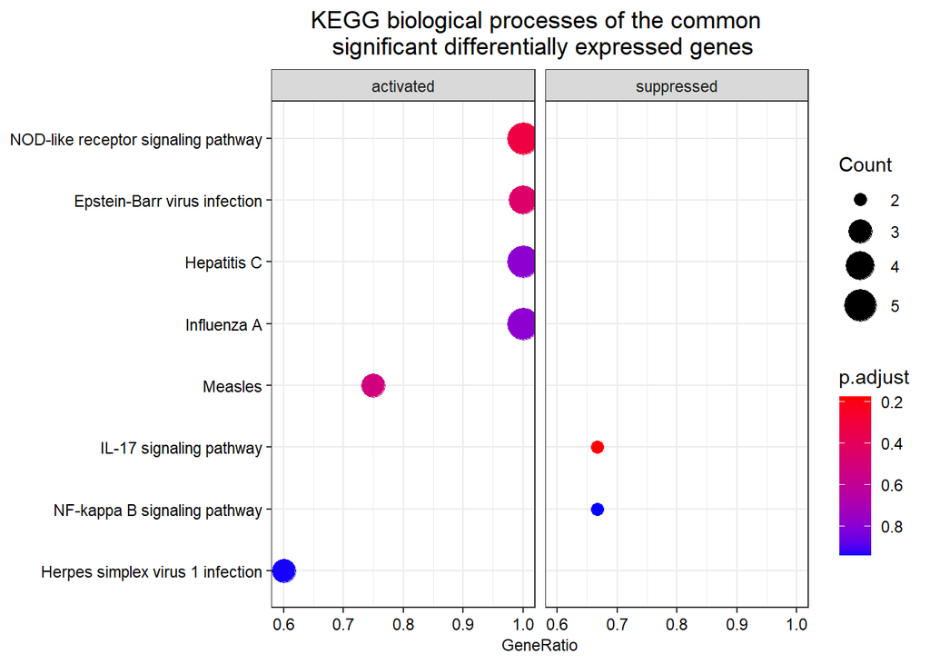

```r
dds_lung_results_sub <- dds_lung_results %>%
  filter(
  gene %in% c("IFI6", "GBP5", "S100A9", "S100A12", "S100A8", "IFITM1", "OAS1" , "OAS3", "OAS2", "C15orf48", "BCL2A1", "TNFSF14", "MX2", "MX1" , "TNF"))

## EXTRACTING THE FOLD CHANGES FOR KEGG ANALYSIS
foldchanges_ent_sub <- dds_lung_results_sub$log2FoldChange
names(foldchanges_ent_sub) <- dds_lung_results_sub$entrezgene_id
foldchanges_ent_sub <- sort(foldchanges_ent_sub, decreasing = TRUE)

gse_KEGG_com <- gseKEGG(geneList = foldchanges_ent_sub,
              organism = "hsa",
              minGSSize = 3,
              maxGSSize    = 100,
              pvalueCutoff = "none",
              pAdjustMethod = "none",
              keyType       = "ncbi-geneid")

dotplot(gse_KEGG_com, title = "KEGG biological processes of the common \n significant differentially expressed genes", font.size = 8.5, split=".sign") + facet_grid(.~.sign) + theme(plot.title = element_text(hjust = 0.5))
```

The KEGG pathway `hsa04621 - NOD-like receptor signalling pathway`, for example, contains **5** common differentially expressed genes. This pathway activates downstream molecules (such as NF-κB) through signal transduction to mediate the production of **pro-inflammatory cytokines**.

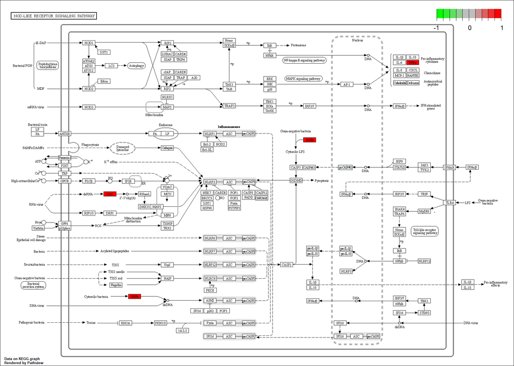

```r
KEGG_pathway <- pathview(gene.data=foldchanges_ent_sub, pathway.id="hsa04621", species = "hsa")

knitr::include_graphics("hsa04621.pathview.png")
```

## 8. Conclusion

The current project analysed the transcriptional response using RNA sequencing to cell model of SARS-CoV-2 infection and COVID-19 lung biopsy. The methods and tools applied suggested genes/pathways that may be involved SARS-CoV-2 infection, however, it is recommended to perform experimental validation of any suggested pathways.

> Overall, the results revealed a **cascade of inflammatory responses** mediated by pathways such as cell chemotaxis, cytokine-cytokine receptor interaction, cytokine production and NOD-like receptor signalling pathway.

## 9. References

`RNA-seq dataset`: Daniel Blanco-Melo, Benjamin E. Nilsson-Payant, Wen-Chun Liu, Rasmus Møller, Maryline Panis, David Sachs, Randy A. Albrecht, Benjamin R. tenOever. SARS-CoV-2 launches a unique transcriptional signature from in vitro, ex vivo, and in vivo systems bioRxiv 2020.03.24.004655; doi: https://doi.org/10.1101/2020.03.24.004655 / https://www.ncbi.nlm.nih.gov/geo/query/acc.cgi?acc=GSE147507

`DESeq2`package: Love MI, Huber W, Anders S (2014). “Moderated estimation of fold change and dispersion for RNA-seq data with DESeq2.” Genome Biology, 15, 550. doi: 10.1186/s13059-014-0550-8.

`clusterProfiler` package: Guangchuang Yu, Li-Gen Wang, Yanyan Han and Qing-Yu He. clusterProfiler: an R package for comparing biological themes among gene clusters. OMICS: A Journal of Integrative Biology 2012, 16(5):284-287

`DOSE` package: Guangchuang Yu, Li-Gen Wang, Guang-Rong Yan, Qing-Yu He. DOSE: an R/Bioconductor package for Disease Ontology Semantic and Enrichment analysis. Bioinformatics 2015, 31(4):608-609

`pathview` package: Luo, W. and Brouwer C., Pathview: an R/Bioconductor package for pathway-based data integration and visualization. Bioinformatics, 2013, 29(14): 1830-1831, doi: 10.1093/bioinformatics/btt285

`apeglm` for LFC shrinkage: Zhu, A., Ibrahim, J.G., Love, M.I. (2018) Heavy-tailed prior distributions for sequence count data: removing the noise and preserving large differences. Bioinformatics. https://doi.org/10.1093/bioinformatics/bty895

`biomaRt` package: Durinck S, Spellman P, Birney E, Huber W (2009). “Mapping identifiers for the integration of genomic datasets with the R/Bioconductor package biomaRt.” Nature Protocols, 4, 1184–1191.

Durinck S, Moreau Y, Kasprzyk A, Davis S, De Moor B, Brazma A, Huber W (2005). “BioMart and Bioconductor: a powerful link between biological databases and microarray data analysis.” Bioinformatics, 21, 3439–3440.

`org.Hs.eg.db` package: Marc Carlson (2020). org.Hs.eg.db: Genome wide annotation for Human. R package version 3.11.1.

`GEOquery` package: Davis S, Meltzer P (2007). “GEOquery: a bridge between the Gene Expression Omnibus (GEO) and BioConductor.” Bioinformatics, 14, 1846–1847.